# JABBA3 user guide

# 11 Check 4: residual diagnostics

## 11.1 One-step-ahead residuals

The residuals of a state-space model computed from the smoothed states are shrunk and autocorrelated by construction, so the classic tests are biased. JABBA3 computes **one-step-ahead (OSA) residuals** (Thygesen et al. 2017) by a particle filter (`jb3_osa()`, run by `jabba3(osa = TRUE)`): each observation is predicted from the data up to the previous one. Under a correct model they are independent N(0, 1).

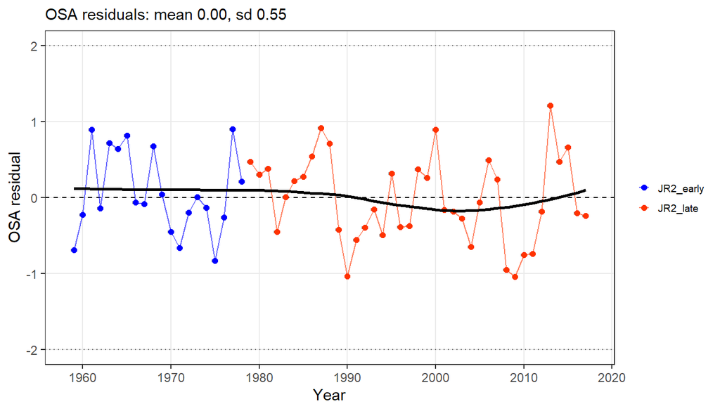

```r
jbplot_residuals(fit)
```

`jbplot_residuals(fit, type = "ordinary")` shows the classic log residuals.

`jbplot_stdresiduals()` shows the ordinary residuals standardised by the total observation SD, as JABBA’s plot of the same name, with SDNR and its 95% critical value:

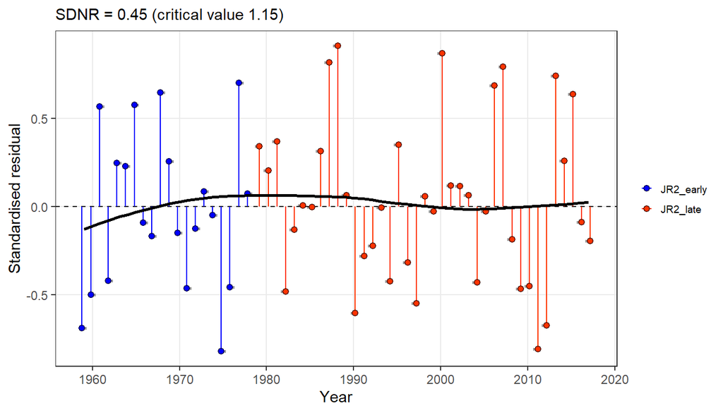

```r
jbplot_stdresiduals(fit)
```

## 11.2 Posterior predictive check

`jbplot_ppc()` compares, draw by draw, the discrepancy of the observed indices from the fitted ones, $D = \sum ((\log I - \log \hat{I})/\sigma)^2$, with that of indices replicated from the observation model (as JABBA’s `jbplot_PPC()`). The Bayesian p-value $P(D^{rep} > D^{obs})$ is near 0.5 for a well-specified observation model; values near 1 mean the indices are fitted more closely than the observation error implies (here the process error absorbs part of the index variation), values near 0 that they are fitted less well. It uses the draws of the fit (NUTS or MVN) and generates MVN draws if there are none.

```r
pp <- jbplot_ppc(fit)
attr(pp, "ppc")
```

```
#>               index Bayesian.p nobs
#> JR2_early JR2_early      0.960   20
#> JR2_late   JR2_late      0.992   39
```

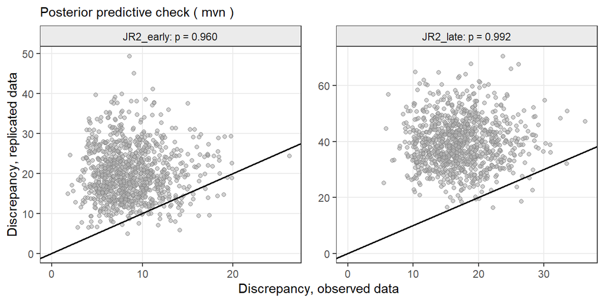

```r
pp
```

## 11.3 Runs tests

The runs test (Wald-Wolfowitz) checks for too few runs of residual signs (autocorrelation), with three-sigma limits from the average moving range (as JABBA, ss3diags and JAGG). Green: passed ($p \ge 0.05$); red: failed.

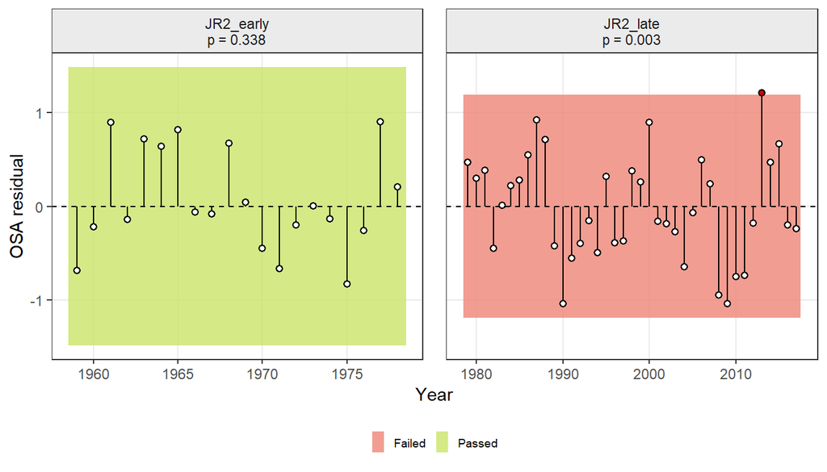

```r
jbplot_runs(fit)
```

The test table is in the plot’s attribute `"runs"` (`attr(jbplot_runs(fit), "runs")`); `mixing = "two.sided"` also flags too many runs. Likewise `jbplot_retro()` and `jbplot_hcxval()` return Mohn’s rho and MASE in attributes `"rho"` and `"mase"`.

## 11.4 The JABBA and SPiCT test sets

`jb3_diags()` gives one table per index: RMSE, SDNR, runs test and the share outside the three-sigma limits (the JABBA set), and the bias t-test, Ljung-Box test (lag 4) and Shapiro-Wilk normality test (the SPiCT set, as `plotspict.diagnostic()`). `flag` is `TRUE` when any test has $p < 0.05$.

```r
jb3_diags(fit)
```

```
#>       index  n       RMSE      SDNR runs.p out.3sig
#> 1 JR2_early 20 0.09463001 0.5445261  0.338        0
#> 2  JR2_late 39 0.09106039 0.5624106  0.003        0
#>      bias.p  LjungBox.p Shapiro.p  flag
#> 1 0.6377573 0.662768600 0.1168457 FALSE
#> 2 0.7878223 0.001439274 0.6813657  TRUE
```

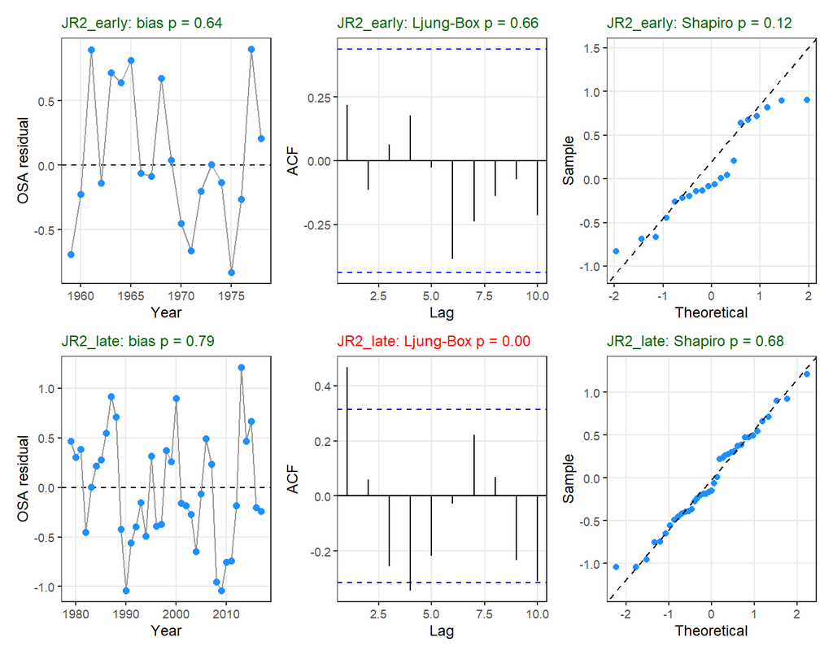

```r
jbplot_spdiags(fit)
```

> Residual tests check the error assumptions; they have little power to detect structural misspecification such as an omitted production lag. Use the retrospective and hindcast as well.

## 11.5 Retrospective analysis

`jb3_retro()` refits with the last 1 to `n` years of all data removed and computes Mohn’s rho.

```r
rt <- jb3_retro(fit, n = 5)
rt$rho
```

```
#>        quantity         rho
#> B             B -0.02622451
#> B/Bmsy   B/Bmsy -0.03492204
#> F             F  0.03281384
#> F/Fmsy   F/Fmsy  0.05993857
```

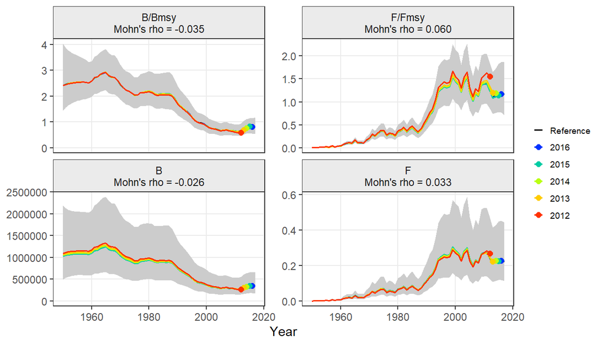

```r
jbplot_retro(rt)
```

## 11.6 Hindcast cross-validation

`jb3_hindcast()` removes the last 1 to `n` years of the indices (catch kept), predicts each removed observation one step ahead, and computes the mean absolute scaled error (MASE; Kell et al. 2021; Carvalho et al. 2021), the prediction error relative to a naive prediction (the last observed value). MASE < 1: the model predicts better than the naive guess.

```r
hc <- jb3_hindcast(fit, n = 5)
hc$mase
```

```
#>               index     MASE MASE.adj   MAE.PR  MAE.base
#> JR2_early JR2_early       NA       NA       NA        NA
#> JR2_late   JR2_late 1.177297 1.177297 0.161752 0.1373927
#>           n.eval
#> JR2_early      0
#> JR2_late       5
```

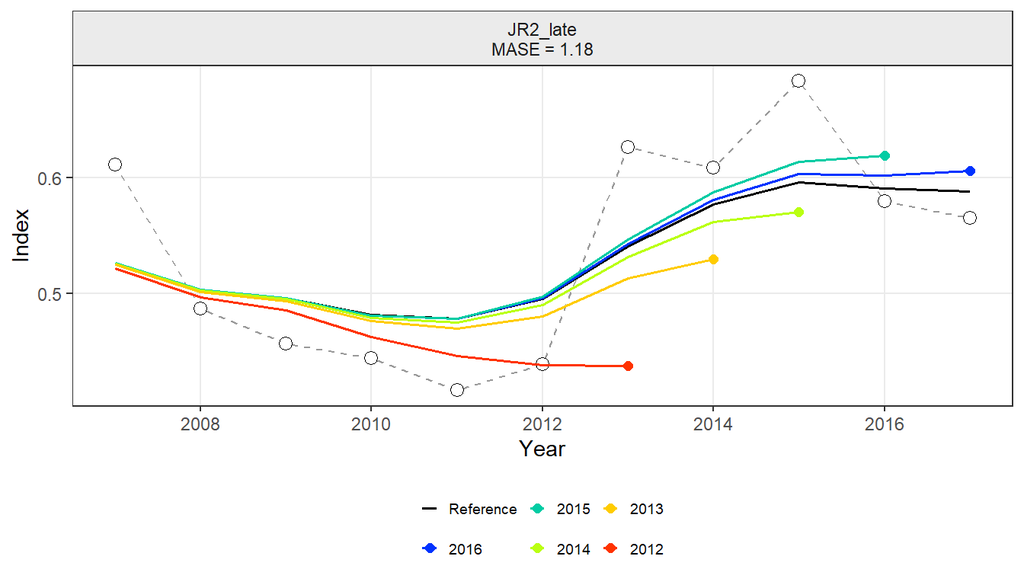

| What | Red flag | Action |
| --- | --- | --- |
| OSA residuals | trends, runs test failed | lag, AR(1), index conflict; separate `sdi` |
| Ljung-Box | p < 0.05 | autocorrelated residuals: process error persistence (AR(1)), or index trends in q |
| Mohn’s rho | beyond -0.15 to 0.20 | retrospective pattern; check recent data and q |
| MASE | > 1 | no prediction skill for that index |

```r
jbplot_hcxval(hc)
```

# 12 NUTS diagnostics

> **Requirements.** NUTS runs through `tmbstan`, which needs `rstan` and a C++ toolchain (Rtools on Windows, Xcode command-line tools on macOS); see chapter *Installation*. Without them, `engine = "nuts"` stops with a message, and everything else in JABBA3 works.

A NUTS fit has to be checked for convergence of the chains before its posterior is used. `jb3_nuts_diags()` gives the rank-normalised split $\hat{R}$, bulk and tail effective sample sizes (ESS; Vehtari et al. 2021) for every sampled parameter, including the states, and the sampler diagnostics by chain: divergent transitions, hits of the maximum tree depth, mean acceptance, step size and the energy Bayesian fraction of missing information (E-BFMI).

```r
nd <- jb3_nuts_diags(fn)
nd$sampler
```

```
#>   chain divergent treedepth.max    accept   stepsize
#> 1     1         0             0 0.9562879 0.04839334
#> 2     2         0             0 0.9687259 0.04238253
#> 3     3         0             0 0.9473518 0.05129778
#>       EBFMI
#> 1 0.5726484
#> 2 0.5429795
#> 3 0.5150355
```

```r
head(nd$pars, 8)
```

```
#>         par       mean        sd       q2.5        q50
#> 1      logK  3.1840591 0.3079632  2.6316830  3.1648465
#> 2      logr -1.8396691 0.3272653 -2.5360110 -1.8201697
#> 3   logq[1] -3.0823234 0.3222251 -3.7493911 -3.0668081
#> 4   logq[2] -2.4861707 0.3375889 -3.2139654 -2.4651245
#> 5       lbk -0.1625863 0.2181555 -0.6139951 -0.1542193
#> 6    logsdb -2.2971162 0.1953546 -2.6997249 -2.2931062
#> 7 logsdi[1] -2.9643701 0.4932197 -3.8763566 -2.9739349
#> 8 logsdi[2] -3.1096096 0.4311645 -3.9225973 -3.1116435
#>        q97.5     Rhat  ess_bulk ess_tail
#> 1  3.8601721 1.000607 1472.7931 1936.210
#> 2 -1.2488127 1.000317 1742.3577 2043.575
#> 3 -2.4916579 1.002058 1292.2032 2377.191
#> 4 -1.8847610 1.002025 1168.5163 1530.205
#> 5  0.2345981 1.000739 2266.9709 3235.790
#> 6 -1.9253565 1.006455  738.0195 1597.482
#> 7 -1.9948770 1.000503 8416.6299 4687.407
#> 8 -2.2748638 1.000128 7963.2370 4546.695
```

```r
nd$ok
```

```
#> [1] TRUE
```

`ok` is `TRUE` when $\hat{R} < 1.01$, bulk and tail ESS > 100 per chain, there are no divergent transitions and E-BFMI > 0.3 in all chains.

The plots are on the sampled scale (mostly logs): `logK`, `logr`, `logq[i]`, `lbk` (log initial depletion), `logsdb`, `logsdi[i]`, and the states `logP[t]` and catch deviations `cdev[t]`. By default only the fixed effects are plotted; `pars` selects parameters (`"logq"` matches all `logq[i]`).

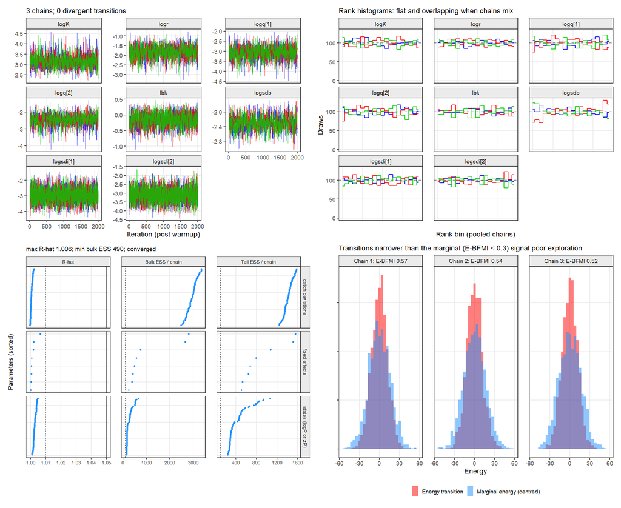

```r
jbplot_nutsdiags(fn)
```

`jbplot_nuts(fit, type)` gives the single plots:

| `type` | Shows | Healthy |
| --- | --- | --- |
| `"trace"` | traces by chain; divergent transitions as red rug ticks | chains overlap, no trends |
| `"rank"` | rank histograms by chain | flat and overlapping |
| `"dens"` | densities by chain | the same in all chains |
| `"acf"` | autocorrelation by chain | drops to zero within a few lags |
| `"pairs"` | pairwise scatter with divergent transitions in red | no funnels or ridges; divergences not clustered |
| `"rhat"` | $\hat{R}$ and ESS for all parameters, states included | $\hat{R} < 1.01$, ESS > 100 per chain |
| `"energy"` | marginal energy against energy transitions | similar widths (E-BFMI > 0.3) |

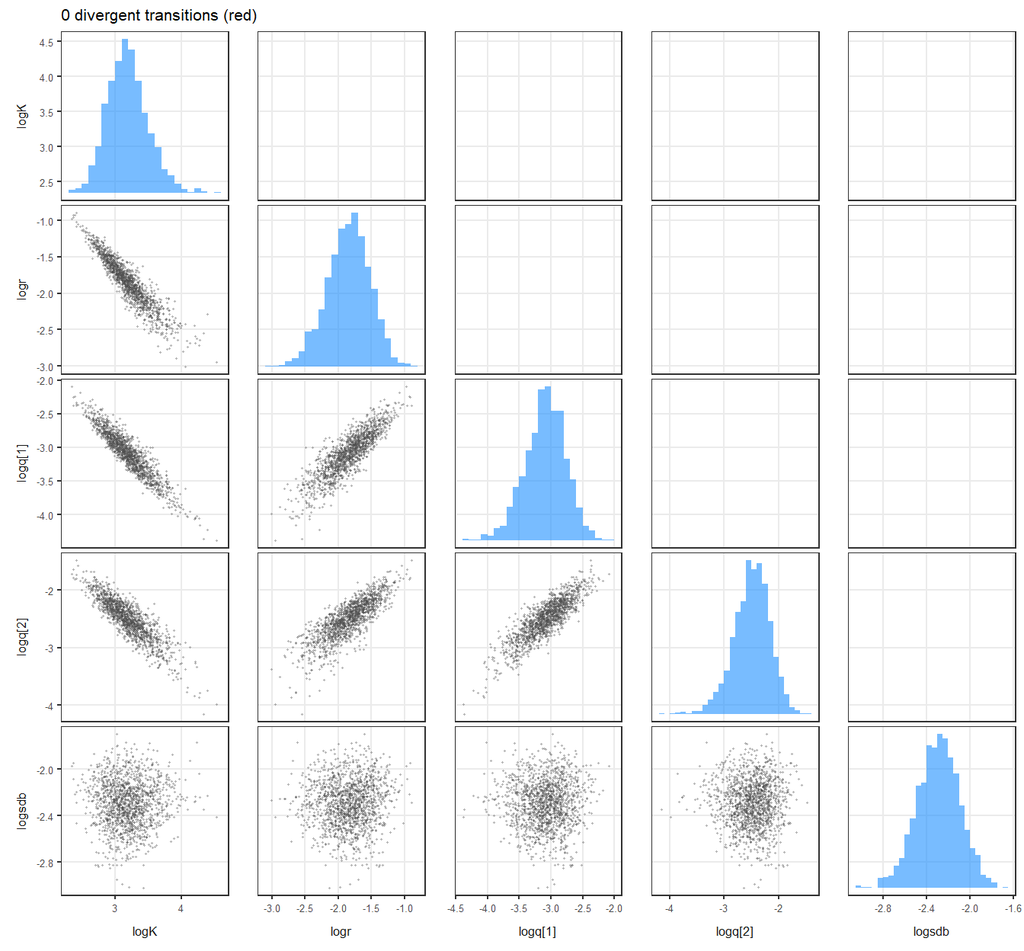

```r
jbplot_nuts(fn, "pairs", pars = c("logK", "logr", "logq", "logsdb"))
```

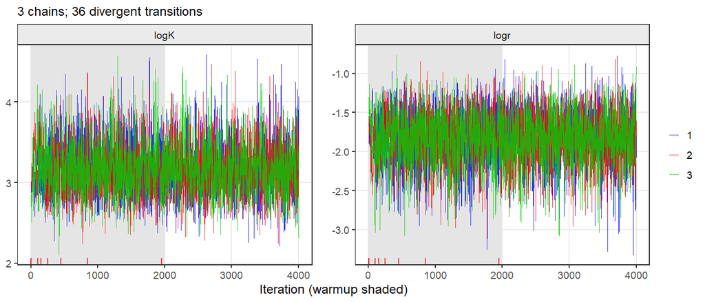

```r
jbplot_nuts(fn, "trace", pars = c("logK", "logr"), inc_warmup = TRUE)
```

Each type is also its own function: `jbplot_trace()`, `jbplot_rank()`, `jbplot_mcmcdens()`, `jbplot_mcmcacf()`, `jbplot_pairs()`, `jbplot_rhat()` and `jbplot_energy()`.

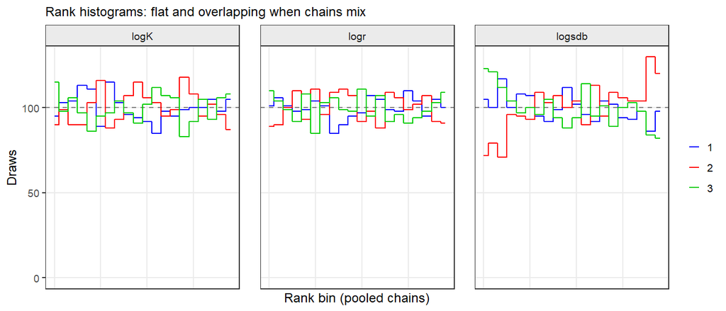

```r
jbplot_rank(fn, pars = c("logK", "logr", "logsdb"))
```

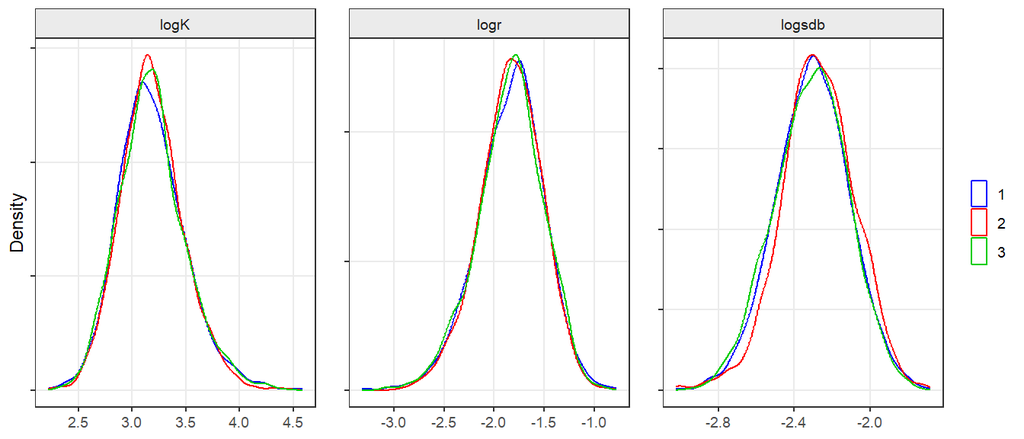

```r
jbplot_mcmcdens(fn, pars = c("logK", "logr", "logsdb"))
```

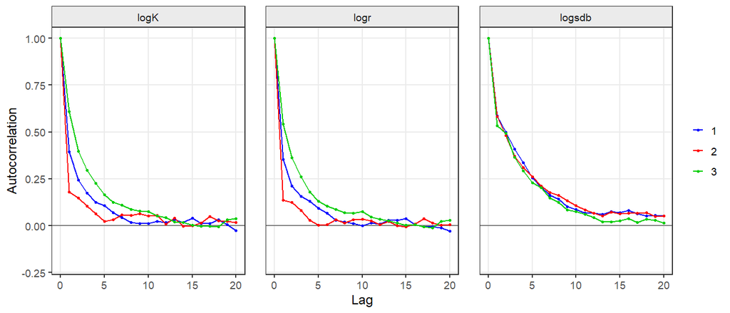

```r
jbplot_mcmcacf(fn, pars = c("logK", "logr", "logsdb"))
```

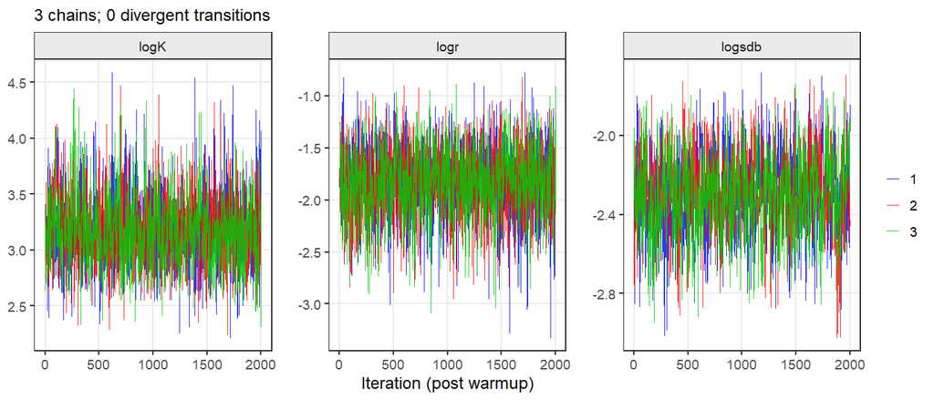

```r
jbplot_trace(fn, pars = c("logK", "logr", "logsdb"))
```

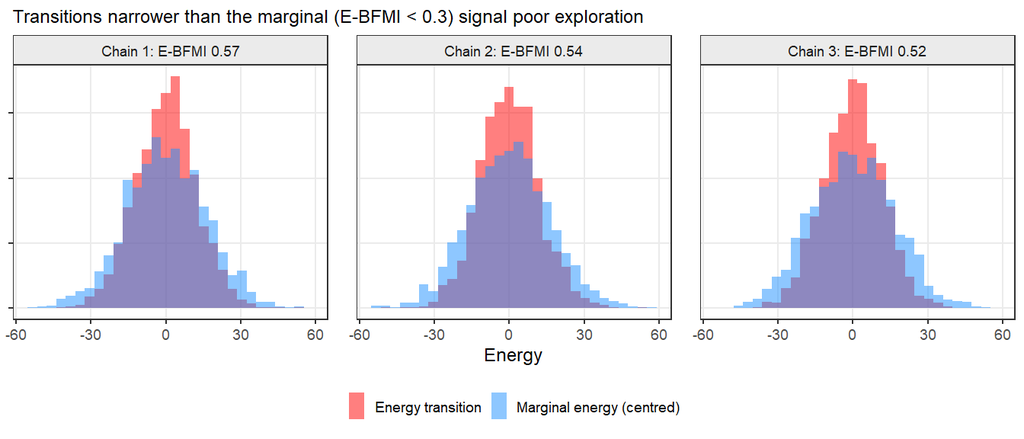

```r
jbplot_energy(fn)
```

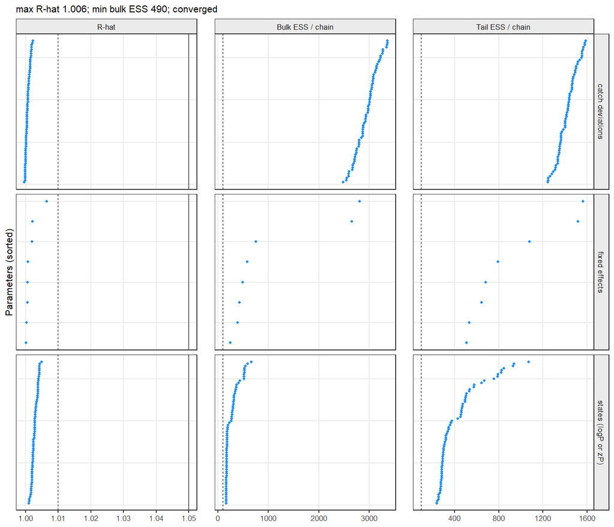

```r
jbplot_rhat(fn)
```

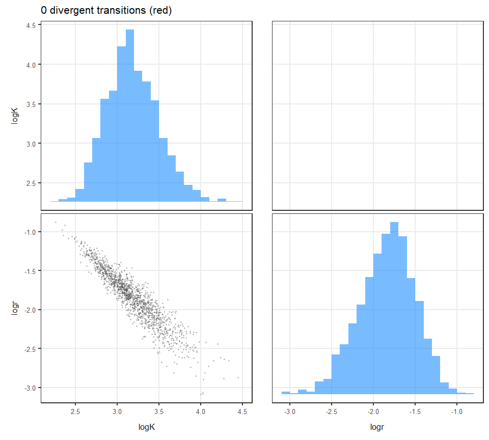

| What | Red flag | Action |
| --- | --- | --- |
| $\hat{R}$, ESS | $\hat{R} > 1.01$ or ESS < 100 per chain | more iterations (`iter`); check the pairs plot |
| divergent transitions | any | `control = list(adapt_delta = 0.99)`; look where they cluster in the pairs plot |
| tree depth | many hits of `max_treedepth` | strong correlations (K and r, K and q): tighter priors |
| E-BFMI | < 0.3 | poor exploration of the tails, often the process error SD and the states |
| K-r-q ridge | strong negative correlation of log K with log r and log q | expected with little contrast; informative r prior |

```r
jbplot_pairs(fn, pars = c("logK", "logr"))
```

> In the short run above the states (`logP`) have low ESS: with process error SDs around 0.1 the states and `logsdb` form a funnel. Run longer for final results.

# 13 BioProcDyn workflows

The workflows of the BioProcDyn protocol run automatically with `jabba3(..., workflow = )`, or step by step with `jb3_tier1()` and `jb3_tier2()` on any fit. All steps are kept in `$steps`.

| `workflow` | Steps |
| --- | --- |
| `"tier1"` | production lag at the age at maturity (`amat`) |
| `"tier2"` | step 1: constant process error (FishLife prior); step 2: dynamic $\sigma_t = \sigma_{MSY} x_t^{-k}$ with the level tuned on step 1, $\sigma_{MSY} = \hat\sigma_1 / \sqrt{\mathrm{mean}(x_{1,t}^{-2k})}$,… |
| `"selex"`, `"selex_tier1"`, `"selex_tier2"` | the same with the spawning-biomass state (needs `model$ebsb`) |

```r
wf <- jabba3(d, pr, jb3_model(shape = "fox"), workflow = "tier2", amat = 3)
names(wf$steps)
```

```
#> [1] "Current" "Tier 2"
```

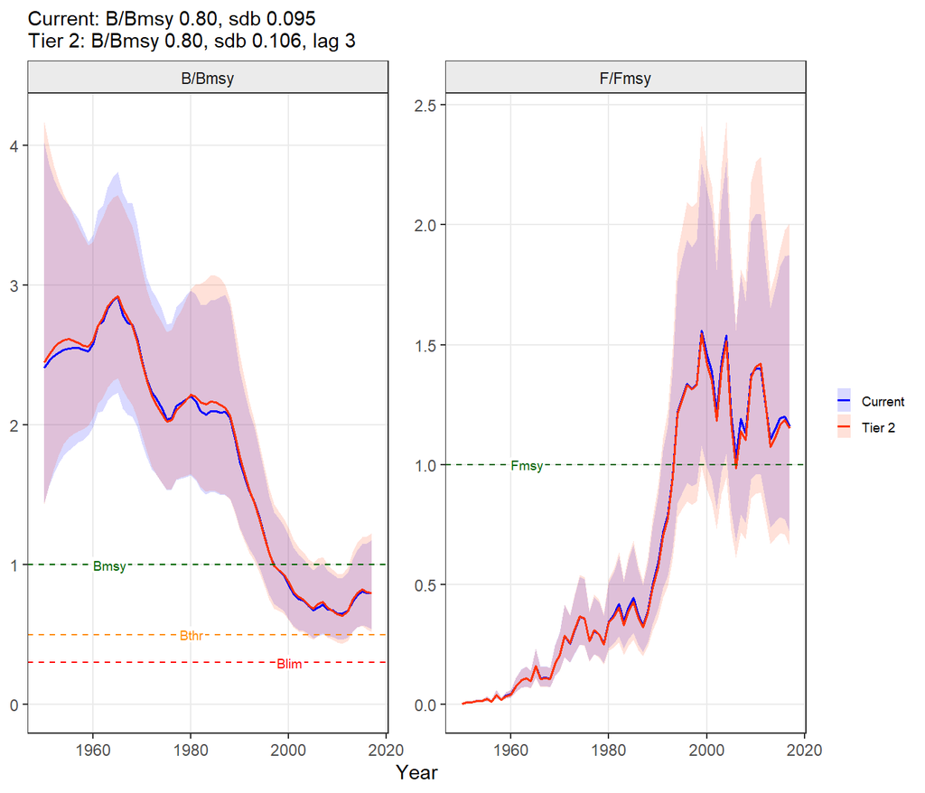

```r
jbplot_steps(wf)
```

Step by step, from an existing fit:

```r
t1 <- jb3_tier1(fit, amat = 3)
t1$model$lag
```

```
#> [1] 3
```

> The BioProcDyn simulations found that the depletion-dependent process error of Tier 2, although present in the operating models, did not remove the optimism; lag + AR(1) (`jb3_model(lag = amat, rho = 0.75)`) did. The tiers are kept for comparison and sensitivity.

# 14 Projections

`jb3_project()` projects the stock under constant $F/F_{MSY}$ scenarios (`fmsy`, the default: 0, 0.5, 0.75, 1 and 1.25 $F_{MSY}$) or constant catch (`catch`), from the NUTS draws or from MVN draws at the mode (generated if the fit has none), with process error (and its AR(1) persistence and the lag). F-based scenarios apply $F = f \times F_{MSY}$ draw by draw, so they remain defined when a draw is depleted; constant catches are capped at 95% of the biomass.

```r
pj <- jb3_project(fit, fmsy = c(0, 0.5, 0.75, 1, 1.25), nyears = 10)
pj$scenarios
```

```
#>     type value         label
#> 1 F/Fmsy  0.00    F/Fmsy = 0
#> 2 F/Fmsy  0.50  F/Fmsy = 0.5
#> 3 F/Fmsy  0.75 F/Fmsy = 0.75
#> 4 F/Fmsy  1.00    F/Fmsy = 1
#> 5 F/Fmsy  1.25 F/Fmsy = 1.25
```

Process error in the projection years follows the fitted model. With the default `procerr = "ar1"`, each draw continues its AR(1) process from its last estimated deviation, $d_{t+1} = \rho d_t + \varepsilon_t$ with $\varepsilon_t \sim N(0, \sigma^2(1-\rho^2))$, so the persistence carries into the forecast and the marginal SD stays $\sigma$ (with $\rho = 0$ this is the iid sampling of JABBA’s `fw_jabba()`). `procerr = "mean"` uses only the conditional mean $\rho^h d_T$ and `"none"` deterministic production. Projection tables report the risk $P(B < B_{lim})$ with $B_{lim} = 0.3 B_{MSY}$ by default.

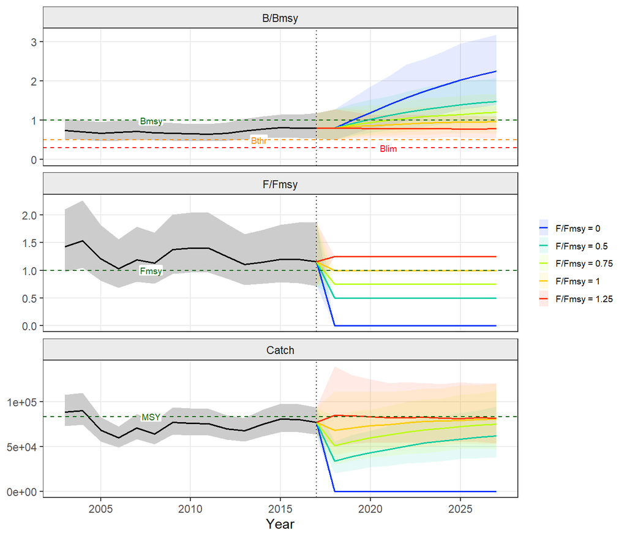

```r
jbplot_projection(pj)
```

`jbplot_projection()` draws $B_{MSY}$ and $F_{MSY}$ (green), MSY on the catch panel, a biomass threshold `bthr` (orange, default $0.5 B_{MSY}$) and limit `blim` (red, default $0.3 B_{MSY}$). A name sets the label, e.g. `bthr = c(Bpa = 0.5)` (ICES) or `bthr = c(MSST = 1 - M)` (U.S.), `NULL` omits one, and `extra` adds further lines, e.g. `extra = c(Flim = 1.3)`:

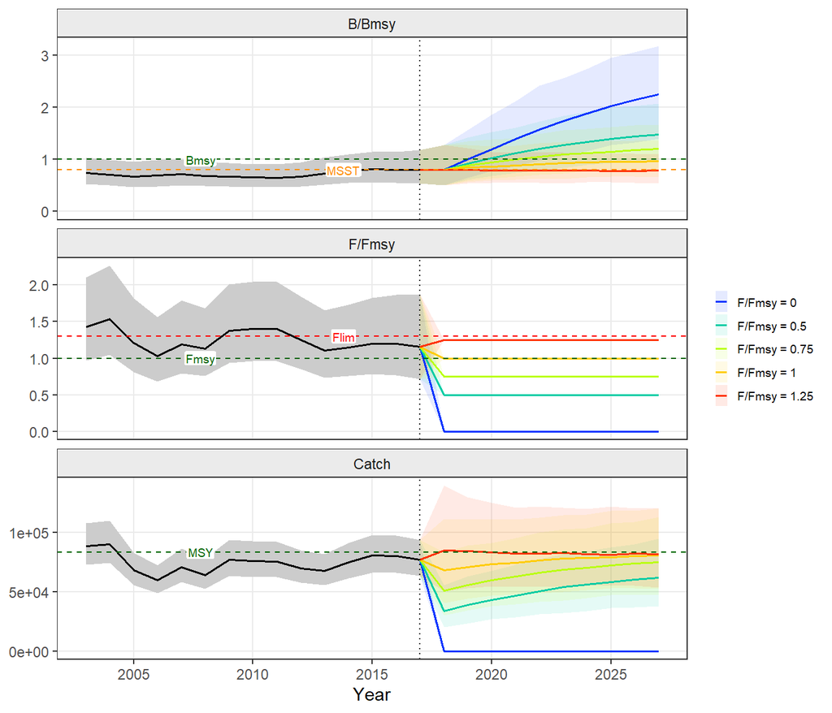

```r
jbplot_projection(pj, bthr = c(MSST = 1 - 0.2), blim = NULL, extra = c(Flim = 1.3))
```

## 14.1 Projections on the advice plot

`jbplot_advice(fit, proj = )` appends the projection scenarios (dashed) to the assessment advice plot:

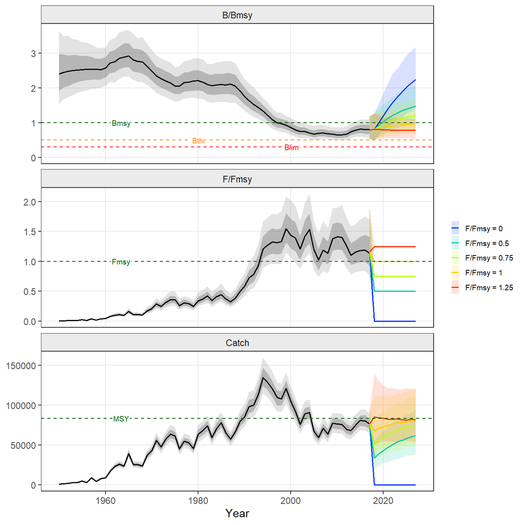

```r
jbplot_advice(fit, proj = pj)
```

## 14.2 Projection tables

`jb3_projtable()` gives a catch options table in the style of an ICES advice sheet: $F/F_{MSY}$, $F$ and the catch in the first projection year, the median $B/B_{MSY}$ in selected years with the change relative to the terminal year, and the probabilities of $B \ge B_{MSY}$, $F \le F_{MSY}$ and of the Kobe green quadrant.

```r
knitr::kable(jb3_projtable(pj, years = c(2018, 2022, 2027)))
```

| scenario | F/Fmsy | F | Catch 2018 | B/Bmsy 2018 | dB% 2018 | P(B>=Bmsy) 2018 | P(B<Blim) 2018 | P(F<=Fmsy) 2018 | P(green) 2018 | B/Bmsy 2022 | dB% 2022 | P(B>=Bmsy) 2022 | P(B<Blim) 2022 | P(F<=Fmsy) 2022 | P(green) 2022 | B/Bmsy 2027 | dB% 2027 | P(B>=Bmsy) 2027 | P(B<Blim) 2027 | P(F<=Fmsy) 2027 | P(green) 2027 |
| --- | --- | --- | --- | --- | --- | --- | --- | --- | --- | --- | --- | --- | --- | --- | --- | --- | --- | --- | --- | --- | --- |
| F/Fmsy = 0 | 0.00 | 0.0000 | 0 | 0.807 | 0.757 | 0.176 | 0 | 1 | 0.176 | 1.580 | 97.20 | 0.966 | 0 | 1 | 0.966 | 2.250 | 180.00 | 0.997 | 0 | 1 | 0.997 |
| F/Fmsy = 0.5 | 0.50 | 0.0967 | 34000 | 0.807 | 0.757 | 0.176 | 0 | 1 | 0.176 | 1.210 | 50.60 | 0.801 | 0 | 1 | 0.801 | 1.480 | 85.20 | 0.964 | 0 | 1 | 0.964 |
| F/Fmsy = 0.75 | 0.75 | 0.1450 | 51000 | 0.807 | 0.757 | 0.176 | 0 | 1 | 0.176 | 1.050 | 30.80 | 0.603 | 0 | 1 | 0.603 | 1.200 | 50.40 | 0.825 | 0 | 1 | 0.825 |
| F/Fmsy = 1 | 1.00 | 0.1930 | 68000 | 0.807 | 0.757 | 0.176 | 0 | 1 | 0.176 | 0.911 | 13.80 | 0.304 | 0 | 1 | 0.304 | 0.972 | 21.40 | 0.424 | 0 | 1 | 0.424 |
| F/Fmsy = 1.25 | 1.25 | 0.2420 | 85000 | 0.807 | 0.757 | 0.176 | 0 | 0 | 0.000 | 0.786 | -1.81 | 0.087 | 0 | 0 | 0.000 | 0.786 | -1.88 | 0.070 | 0 | 0 | 0.000 |

`jb3_kobematrix()` is the Kobe II strategy matrix (ICCAT): the probability of being in the green quadrant by scenario and year (`what = "B"` or `"F"` for one reference point only).

```r
knitr::kable(jb3_kobematrix(pj))
```

| F/Fmsy | 2018 | 2019 | 2020 | 2021 | 2022 | 2023 | 2024 | 2025 | 2026 | 2027 |
| --- | --- | --- | --- | --- | --- | --- | --- | --- | --- | --- |
| 0.00 | 0.18 | 0.51 | 0.79 | 0.92 | 0.97 | 0.98 | 1.00 | 1.00 | 1.00 | 1.00 |
| 0.50 | 0.18 | 0.36 | 0.55 | 0.71 | 0.80 | 0.88 | 0.92 | 0.95 | 0.96 | 0.96 |
| 0.75 | 0.18 | 0.30 | 0.40 | 0.51 | 0.60 | 0.67 | 0.72 | 0.78 | 0.81 | 0.82 |
| 1.00 | 0.18 | 0.23 | 0.23 | 0.27 | 0.30 | 0.35 | 0.35 | 0.38 | 0.41 | 0.42 |
| 1.25 | 0.00 | 0.00 | 0.00 | 0.00 | 0.00 | 0.00 | 0.00 | 0.00 | 0.00 | 0.00 |

## 14.3 Kobe II strategy matrices

The Kobe II strategy matrix (K2SM) gives, by management option (rows) and projection year (columns), the probability of meeting reference points. `jb3_kobematrix()` computes it from any projection, in the ICCAT format by default; `jb3_kobematrix_iotc()`, `jb3_kobematrix_gfcm()` and `jb3_kobematrix_ices()` give the IOTC, GFCM and ICES formats, and `jbplot_kobematrix()` plots them, shaded in grey as in the report tables (`colours = "grey"`, default) or red to green (`colours = "kobe"`). All scenarios of a projection share the same process-error draws, so intermediate years are identical across rows and the probabilities change monotonically with the option. Each matrix below is computed from the projection plotted just before it.

### 14.3.1 Catch (TAC) options: ICCAT and IOTC

Constant catches of 60-130% of the catch in the last assessment year, after one intermediate year at the status quo catch (`imp.years = 1`):

```r
cref <- tail(fit$data$catch, 1)
pt <- jb3_project(fit, catch = round(cref*seq(0.6, 1.3, 0.1), -2), nyears = 10, imp.years = 1)
```

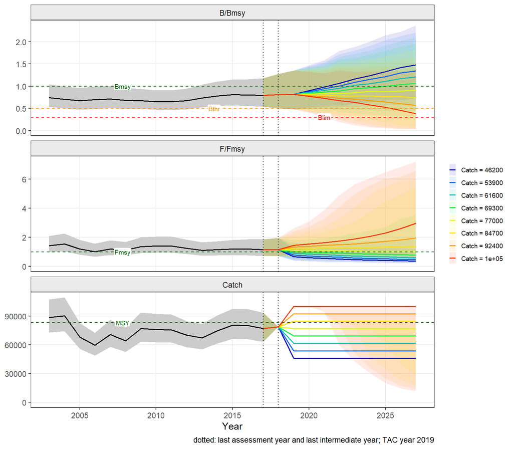

```r
jbplot_projection(pt)
```

The ICCAT matrices (a) $P(F < F_{MSY})$, (b) $P(B > B_{MSY})$ and (c) both (the green Kobe quadrant):

```r
k2 <- jb3_kobematrix(pt, what = "all", percent = TRUE)
k2
```

```
#> a) Probability that F < Fmsy (%)
#>     TAC 2018 2019 2020 2021 2022 2023 2024 2025 2026
#>   46200   28   91   95   96   97   98   98   99   99
#>   53900   28   78   84   88   90   91   93   94   95
#>   61600   28   63   69   73   77   80   81   83   85
#>   69300   28   49   51   56   58   62   63   66   68
#>   77000   28   36   38   41   43   44   45   45   48
#>   84700   28   23   24   28   28   29   28   29   30
#>   92400   28   14   14   14   15   15   15   16   17
#>  100100   28   10    9    7    8    7    7    7    6
#>  2027
#>    99
#>    95
#>    86
#>    68
#>    48
#>    31
#>    16
#>     7
#>
#> b) Probability that B > Bmsy (%)
#>     TAC 2018 2019 2020 2021 2022 2023 2024 2025 2026
#>   46200   18   23   35   48   59   69   76   81   86
#>   53900   18   23   32   43   51   60   67   73   77
#>   61600   18   23   30   38   44   52   57   62   67
#>   69300   18   23   28   34   39   43   47   50   54
#>   77000   18   23   25   29   33   34   36   39   40
#>   84700   18   23   23   24   26   27   28   28   29
#>   92400   18   23   20   21   21   20   19   18   19
#>  100100   18   23   18   18   15   14   13   12   11
#>  2027
#>    88
#>    80
#>    68
#>    55
#>    42
#>    29
#>    19
#>    11
#>
#> c) Probability that F < Fmsy and B > Bmsy (%)
#>     TAC 2018 2019 2020 2021 2022 2023 2024 2025 2026
#>   46200   16   23   35   48   59   69   76   81   86
#>   53900   16   23   32   43   51   60   67   73   77
#>   61600   16   23   30   38   44   52   57   62   67
#>   69300   16   23   28   34   39   43   47   50   54
#>   77000   16   23   24   29   33   34   35   39   40
#>   84700   16   20   19   22   23   26   26   26   28
#>   92400   16   14   13   14   14   14   14   15   15
#>  100100   16   10    8    7    7    7    7    7    6
#>  2027
#>    88
#>    80
#>    68
#>    55
#>    41
#>    28
#>    16
#>     7
```

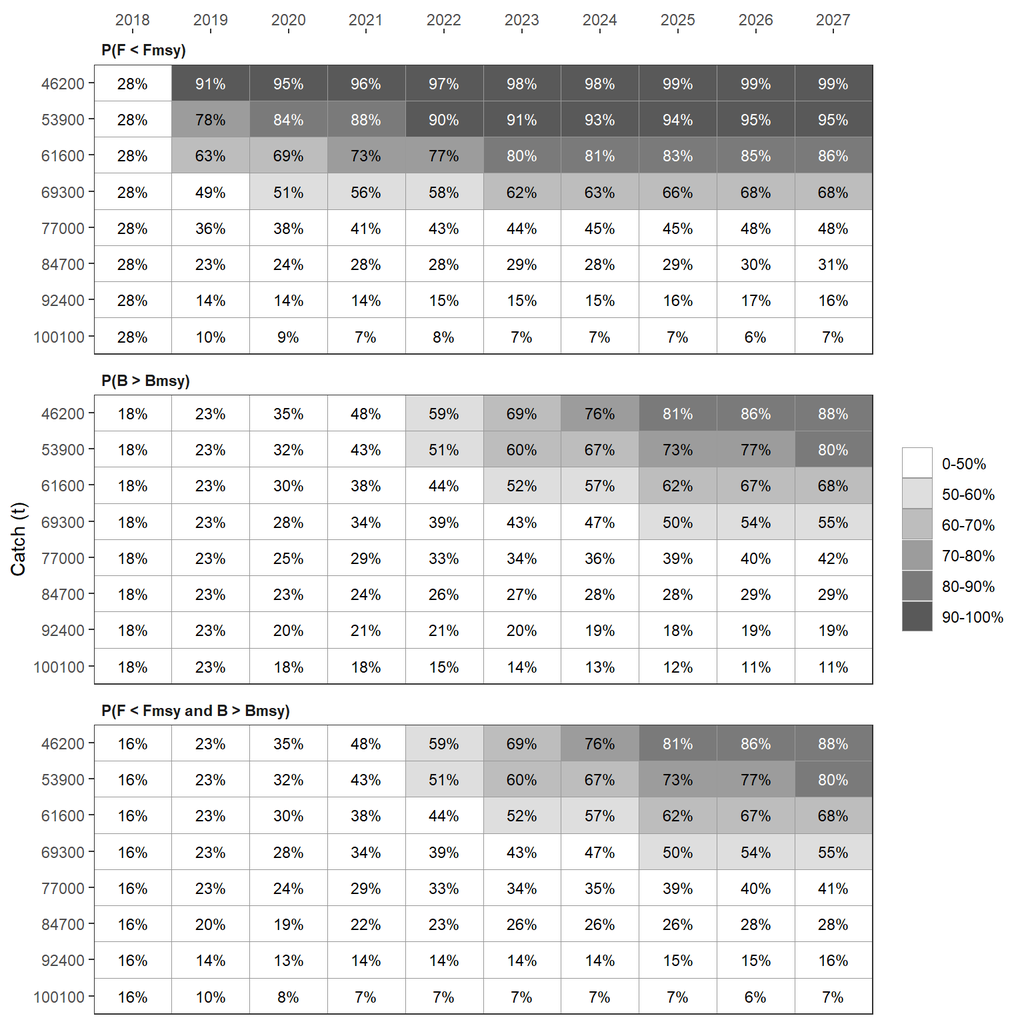

```r
jbplot_kobematrix(pt)
```

`what = "green"` (default), `"B"` or `"F"` returns one matrix, and `percent = FALSE` proportions. Projections from several models (e.g. alternative production functions, or runs with and without the lag) are combined into one matrix with equal or given `weights`, as the ICCAT combined matrices of two base cases:

```r
jb3_kobematrix(list(Fox = pt.fox, Schaefer = pt.sch), what = "all", percent = TRUE)
```

The IOTC format from the same projection: catch options relative to the reference catch, and the probability (%) of violating the MSY-based reference points, $P(B < B_{MSY})$ and $P(F > F_{MSY})$, and the limit reference points, $P(B < B_{lim})$ and $P(F > F_{lim})$ (defaults $B_{lim} = 0.5 B_{MSY}$, $F_{lim} = 1.3 F_{MSY}$; `blim`, `flim`), 3 and 10 years after the last assessment year (`years`):

```r
kio <- jb3_kobematrix_iotc(pt, ref.catch = cref)
kio
```

```
#> Probability (%) of violating MSY-based reference points
#>  Reference point 60% (46,200t) 70% (53,900t)
#>     B2020 < Bmsy          65.2          67.5
#>     F2020 > Fmsy           5.4          15.8
#>     B2027 < Bmsy          12.0          20.3
#>     F2027 > Fmsy           0.8           4.8
#>  80% (61,600t) 90% (69,300t) 100% (77,000t)
#>           69.9          72.4           75.0
#>           31.3          48.7           62.0
#>           32.0          45.0           58.3
#>           13.9          32.0           52.1
#>  110% (84,700t) 120% (92,400t) 130% (100,100t)
#>            77.4           79.7            81.5
#>            75.7           86.2            91.3
#>            70.6           81.3            89.2
#>            69.2           83.5            93.4
#>
#> Probability (%) of violating limit reference points (Blim = 0.5 Bmsy; Flim = 1.3 Fmsy)
#>  Reference point 60% (46,200t) 70% (53,900t)
#>     B2020 < Blim           2.0           2.4
#>     F2020 > Flim           0.9           3.3
#>     B2027 < Blim           0.4           1.0
#>     F2027 > Flim           0.4           1.8
#>  80% (61,600t) 90% (69,300t) 100% (77,000t)
#>            2.8           3.5            4.7
#>            9.6          20.0           32.7
#>            4.1           8.0           17.4
#>            6.4          16.2           34.4
#>  110% (84,700t) 120% (92,400t) 130% (100,100t)
#>             6.5            7.9             9.1
#>            47.0           57.1            69.0
#>            30.3           43.9            60.2
#>            54.1           70.1            83.2
```

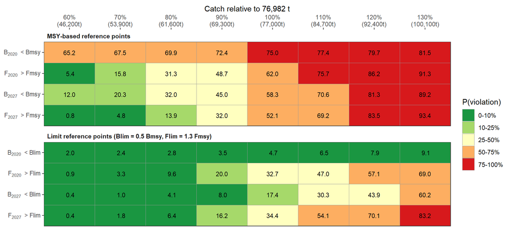

```r
jbplot_kobematrix(kio, colours = "kobe")
```

### 14.3.2 F options: GFCM and ICES

GFCM and ICES advice is usually based on F options. Named scenarios (`scenarios` in `jb3_project()`) are reported in the order and with the names given; each is one named value, with `Catch`, `Fmsy` (F/F<sub>MSY</sub>), `F` (harvest rate), `Fsq` or `Csq` (multipliers of the status quo).

F options relative to $F_{MSY}$ (`Fmsy = 0.8`) apply $F = 0.8 F_{MSY}$ draw by draw, so $P(F < F_{MSY})$ is 0 or 100%. As in the GFCM and ICES forecasts (e.g. SPiCT `add.man.scenario(fabs = )`), the F options are therefore set as absolute harvest rates from the point estimates of $F_{MSY}$ and the current F (mean of the last three years): $F = 0$, 0.5-2 $F_{tgt}$ ($F_{tgt} = F_{MSY}$), $F_{cur}$, and the precautionary $F_{MSY}$ PA (35th percentile of $F_{MSY}$):

```r
rp <- fit$refpts
Fmsy <- rp["Fmsy", "est"]
Fcur <- mean(tail(fit$ts$est[fit$ts$quantity == "F"], 3))
Fmsy.pa <- exp(qnorm(0.35, log(Fmsy), rp["Fmsy", "se.log"]))
mult <- c(0, 0.5, 0.75, 1, 1.25, 1.5, 2)
fopt <- c(setNames(lapply(mult, function(m) c(F = m*Fmsy)),
                   c("F0", "0.5Ftgt", "0.75Ftgt", "Ftgt", "1.25Ftgt", "1.5Ftgt", "2Ftgt")),
          list(Fcur = c(F = Fcur), "Fmsy PA" = c(F = Fmsy.pa)))
pf <- jb3_project(fit, scenarios = fopt, nyears = 10, imp.years = 1)
```

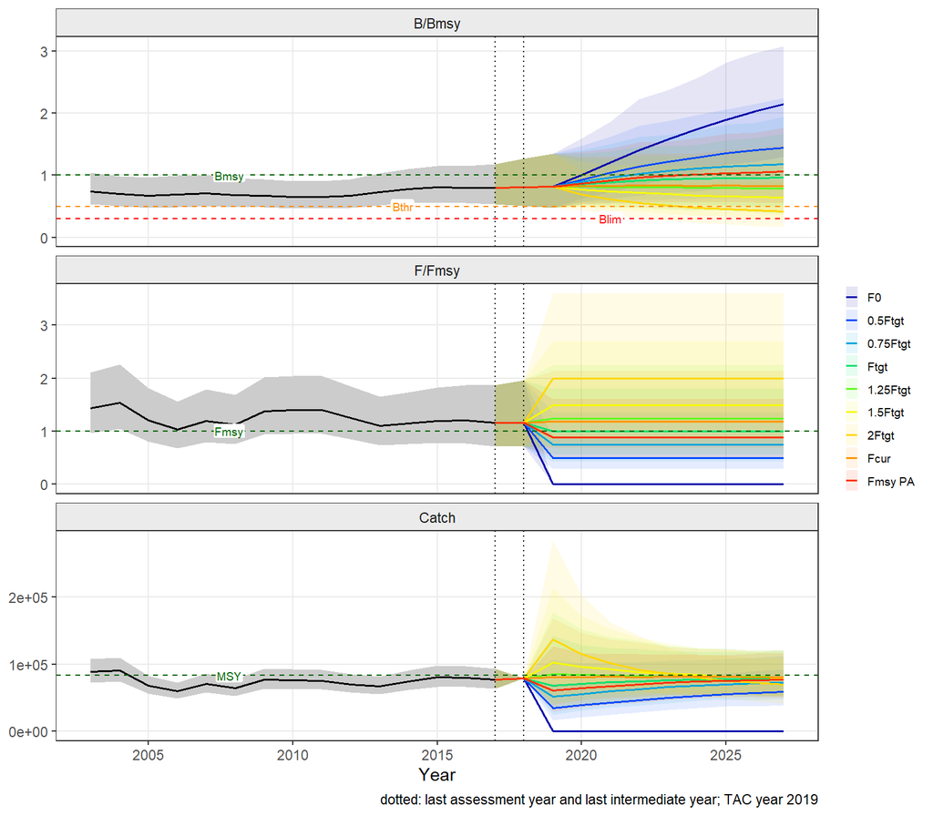

```r
jbplot_projection(pf)
```

With absolute F options, $P(F < F_{MSY})$ is the probability that the option is below the uncertain $F_{MSY}$: 50% for $F_{tgt}$, so the joint probability of the green quadrant cannot exceed 50% at $F_{tgt}$, even where the median biomass is above $B_{MSY}$.

`jb3_kobematrix_gfcm()` gives the three matrices of the GFCM advice summary sheet: (a) $P(F < F_{tgt}$ and $B > B_{tgt})$, (b) $P(B > B_{thr})$ and (c) the risk $P(B < B_{lim})$, with $B_{tgt} = B_{MSY}$, $F_{tgt} = F_{MSY}$, $B_{thr} = 0.5 B_{MSY}$ and $B_{lim} = 0.3 B_{MSY}$ by default (`btgt`, `ftgt`, `bthr`, `blim`):

```r
kg <- jb3_kobematrix_gfcm(pf)
kg
```

```
#> a) Probability that F < Ftgt and B > Btgt (%)
#>  scenario 2018 2019 2020 2021 2022 2023 2024 2025 2026
#>        F0   16   23   51   77   89   96   98   99  100
#>   0.5Ftgt   16   23   39   57   68   76   81   85   88
#>  0.75Ftgt   16   20   29   40   50   57   61   64   67
#>      Ftgt   16   12   17   22   27   31   35   37   38
#>  1.25Ftgt   16    6    8   10   12   15   16   17   18
#>   1.5Ftgt   16    2    3    4    5    5    6    6    6
#>     2Ftgt   16    0    0    1    0    1    1    1    1
#>      Fcur   16    7   10   13   15   20   20   21   22
#>   Fmsy PA   16   15   22   30   37   42   45   49   49
#>  2027
#>   100
#>    90
#>    67
#>    38
#>    18
#>     7
#>     1
#>    23
#>    50
#>
#> b) Probability that B > Bthr (%)
#>  scenario 2018 2019 2020 2021 2022 2023 2024 2025 2026
#>        F0   98   96  100  100  100  100  100  100  100
#>   0.5Ftgt   98   96   99  100  100  100  100  100  100
#>  0.75Ftgt   98   96   99  100  100  100  100  100  100
#>      Ftgt   98   96   98   99   99   98   98   98   98
#>  1.25Ftgt   98   96   98   97   95   93   92   91   91
#>   1.5Ftgt   98   96   96   93   89   85   81   79   75
#>     2Ftgt   98   96   91   77   64   53   45   40   37
#>      Fcur   98   96   98   97   97   96   94   94   93
#>   Fmsy PA   98   96   99   99   99   99   99   99   99
#>  2027
#>   100
#>   100
#>   100
#>    97
#>    89
#>    73
```

[output cut: 10 more lines]

```
#>  1.25Ftgt    0    0    0    0    0    0    0    0    1
#>   1.5Ftgt    0    0    0    0    0    0    1    1    2
#>     2Ftgt    0    0    0    0    2    6   11   17   20
#>      Fcur    0    0    0    0    0    0    0    0    0
#>   Fmsy PA    0    0    0    0    0    0    0    0    0
#>  2027
#>     0
#>     0
#>     0
#>     0
#>     1
#>     4
#>    25
#>     0
#>     0
```

Probabilities are shaded darker (greener) the higher they are, risks darker (redder) the higher the risk, on finer classes (`risk.breaks`):

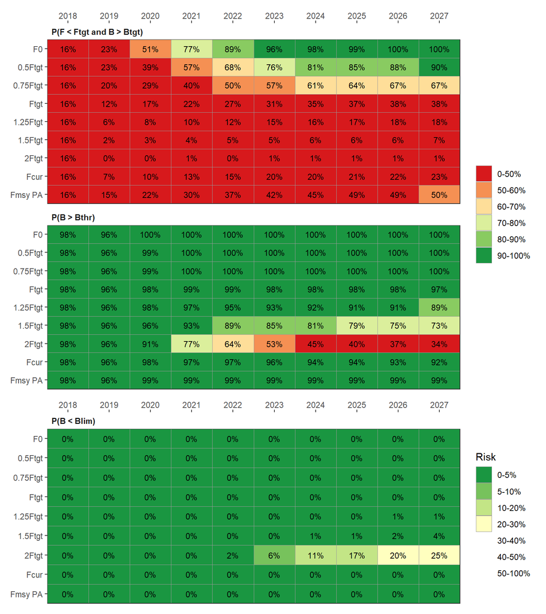

```r
jbplot_kobematrix(kg, colours = "kobe")
```

For ICES-type advice, `jb3_kobematrix_ices()` gives (a) $P(F < F_{MSY}$ and $B > B_{pa})$ and (b) the risk $P(B < B_{lim})$, to compare with the ICES 5% threshold, with the SPM proxies $B_{pa} = 0.5 B_{MSY}$ and $B_{lim} = 0.3 B_{MSY}$ (`bpa`, `blim`):

```r
jb3_kobematrix_ices(pf)
```

Other combinations follow from `jb3_kobematrix()` with `bref` and `fref` (multiples of $B_{MSY}$ and $F_{MSY}$, optionally named; `NULL` drops one) and `risk = TRUE` for the complement, e.g. `jb3_kobematrix(pf, what = "all", bref = c(Btrigger = 0.5))`.

## 14.4 Short-term advice with a hockey-stick HCR

Short-term advice under a harvest control rule (as in the GFCM Type 1 management procedure with JABBA’s `fw_jabba_ctrl()` and `jb_hockeystick()`) takes three steps: a forecast with intermediate years at the status quo catch followed by $F_{tgt}$, the hockey-stick rule applied to $B/B_{MSY}$ in the first implementation (TAC) year to obtain the advised $F_{adv}$, and the forecast of the management options.

Forecast controls (`jb3_fwd()`, as `fw_jabba_ctrl()`) are data frames with one row per year and `quant` `"Catch"`, `"Fmsy"` (F/F<sub>MSY</sub>), `"F"`, `"Csq"`, `"Fsq"` or `"HCR"`; here two intermediate years at the status quo catch (mean of the last three years) and two TAC years:

```r
y0  <- max(fit$years)
yrs <- y0 + 1:4
csq <- mean(tail(fit$data$catch, 3))
fsq <- mean(tail(fit$ts$est[fit$ts$quantity == "F/Fmsy"], 3))
ctrl <- function(v, q) data.frame(year = yrs, value = c(csq, csq, v, v), quant = c("Catch", "Catch", q, q))
ctrl(1, "Fmsy")
```

```
#>   year    value quant
#> 1 2018 79020.93 Catch
#> 2 2019 79020.93 Catch
#> 3 2020     1.00  Fmsy
#> 4 2021     1.00  Fmsy
```

`jb3_hcr()` evaluates the rule ($F/F_{MSY} = F_{tgt}$ above $B_{trigger}$, decreasing linearly below) on $B/B_{MSY}$ in the TAC year of the $F_{tgt}$ forecast. Bigeye is well above the GFCM default $B_{trigger} = 0.5 B_{MSY}$, where the rule hardly changes F; to illustrate the rule, the example uses $B_{trigger} = 0.8 B_{MSY}$:

```r
hcr <- jb3_hcr(jb3_fwd(fit, list(Ftgt = ctrl(1, "Fmsy"))), ftgt = 1, btrigger = 0.8, blim = 0.3)
hcr
```

```
#> Hockey-stick HCR (Ftgt 1.00 Fmsy, Btrigger 0.80 Bmsy) in 2020: B/Bmsy median 0.819, P(B < Btrigger) 0.48
#>   F_adv/Fmsy: 1.000 (median B), 0.909 (precautionary, across draws) -> 0.909
```

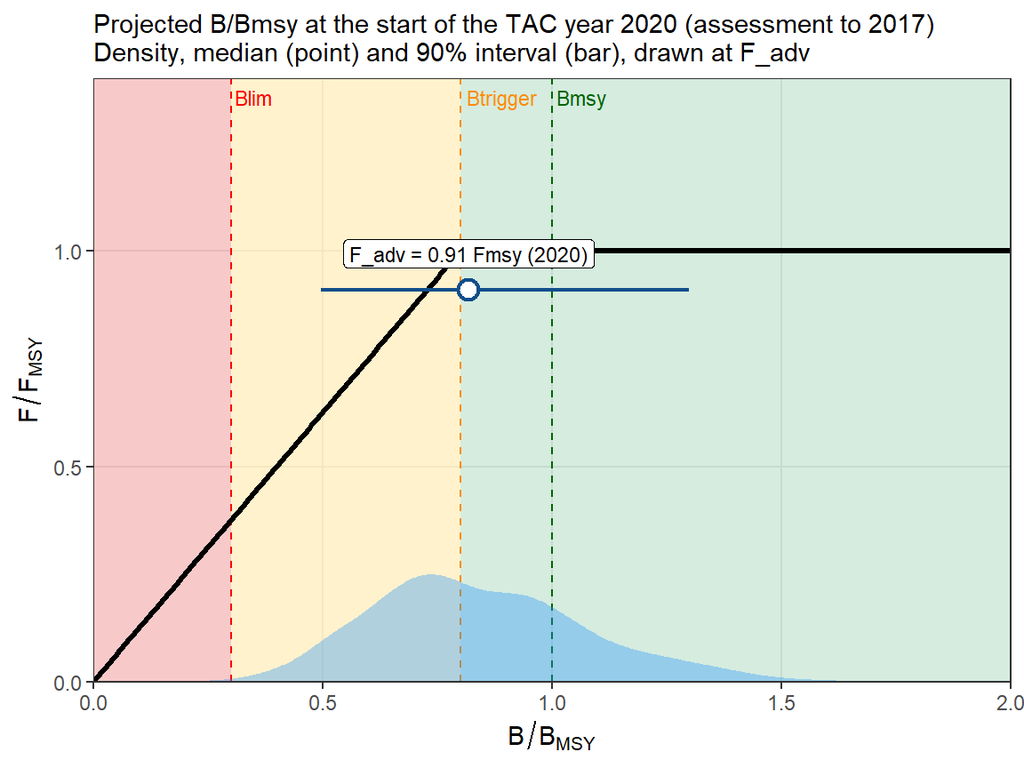

Hockey-stick HCR (black line: F/Fmsy against B/Bmsy) with Blim, Btrigger and Bmsy. The blue density is the projected B/Bmsy at the start of the TAC year: each draw is projected from its terminal-year estimate through the intermediate years at the status quo catch, with process error, so the distribution is wider than the current-state posterior. The point is its median and the horizontal bar its 90% interval, drawn at the height of the advised F (F_adv, precautionary: the rule averaged over all draws).

```r
jbplot_hcr(hcr)
```

The distribution in the plot is not the current state: it is $B/B_{MSY}$ at the start of the TAC year, projected from each draw’s terminal-year estimate through the intermediate years, and so includes their process error. The rule can be evaluated in another forecast year with `year`, e.g. `jb3_hcr(fwd, year = y0 + 1)` for the year after the assessment.

### 14.4.1 Why $F_{adv}$ is below $F_{tgt}$ when the median is above $B_{trigger}$

`jb3_hcr()` offers two ways of turning the uncertain $B/B_{MSY}$ into one advised F:

- **Deterministic** (`uncertainty = FALSE`, `Fadv.det`): the rule is applied once, to the median $B/B_{MSY}$. Here the median is above $B_{trigger}$, so $F_{adv} = F_{tgt}$.
- **Precautionary** (`uncertainty = TRUE`, the default, `Fadv.pa`; as JABBA’s `jb_hockeystick(uncertainty = TRUE)`): the rule is applied to every draw, and the advised F is the mean of the resulting F values, $F_{adv} = \frac{1}{n}\sum_i HCR(B_i/B_{MSY})$. This is an expectation over the draws, not a fractile of $B/B_{MSY}$.

Draws above $B_{trigger}$ get $F_{tgt}$; draws below it get a reduced F, $F_{tgt} (B_i/B_{MSY})/B_{trigger}$ (with `bclose = 0`). Because the rule is capped at $F_{tgt}$, uncertainty can only pull the mean down: the precautionary $F_{adv}$ is never above the deterministic one, and it drops below $F_{tgt}$ as soon as a share of the draws falls below $B_{trigger}$, even when the median is above it. The decomposition:

```r
bt <- 0.8
f.i <- JABBA3:::.hockey(hcr$b, ftgt = 1, btrigger = bt, bclose = 0, fmin = 0.001)   # F/Fmsy for each draw
below <- hcr$b < bt
data.frame(`median B/Bmsy` = median(hcr$b),
           `P(B < Btrigger)` = mean(below),
           `mean F, draws below` = mean(f.i[below]),
           `mean F, draws above` = mean(f.i[!below]),
           `Fadv.det` = hcr$Fadv.det,
           `Fadv.pa` = hcr$Fadv.pa, check.names = FALSE)
```

```
#>   median B/Bmsy P(B < Btrigger) mean F, draws below
#> 1     0.8189105           0.476           0.8094761
#>   mean F, draws above Fadv.det   Fadv.pa
#> 1                   1        1 0.9093106
```

so $F_{adv} = P(B < B_{trigger}) \times \bar F_{below} + (1 - P(B < B_{trigger})) \times F_{tgt}$. The wider the distribution of $B/B_{MSY}$ in the TAC year (larger estimation uncertainty, process error, longer intermediate period), the larger the precautionary reduction. With $B_{trigger} = 0.5 B_{MSY}$ only a few draws are below the trigger and $F_{adv}$ stays close to $F_{tgt}$ (`jb3_hcr(..., btrigger = 0.5)$Fadv`).

### 14.4.2 Management options

The options with $F_{adv}$, $F_{tgt}$, $F_{sq}$, $C_{sq}$ and $F = 0$ in the TAC years, with $B_{trigger}$ marked on the biomass panel:

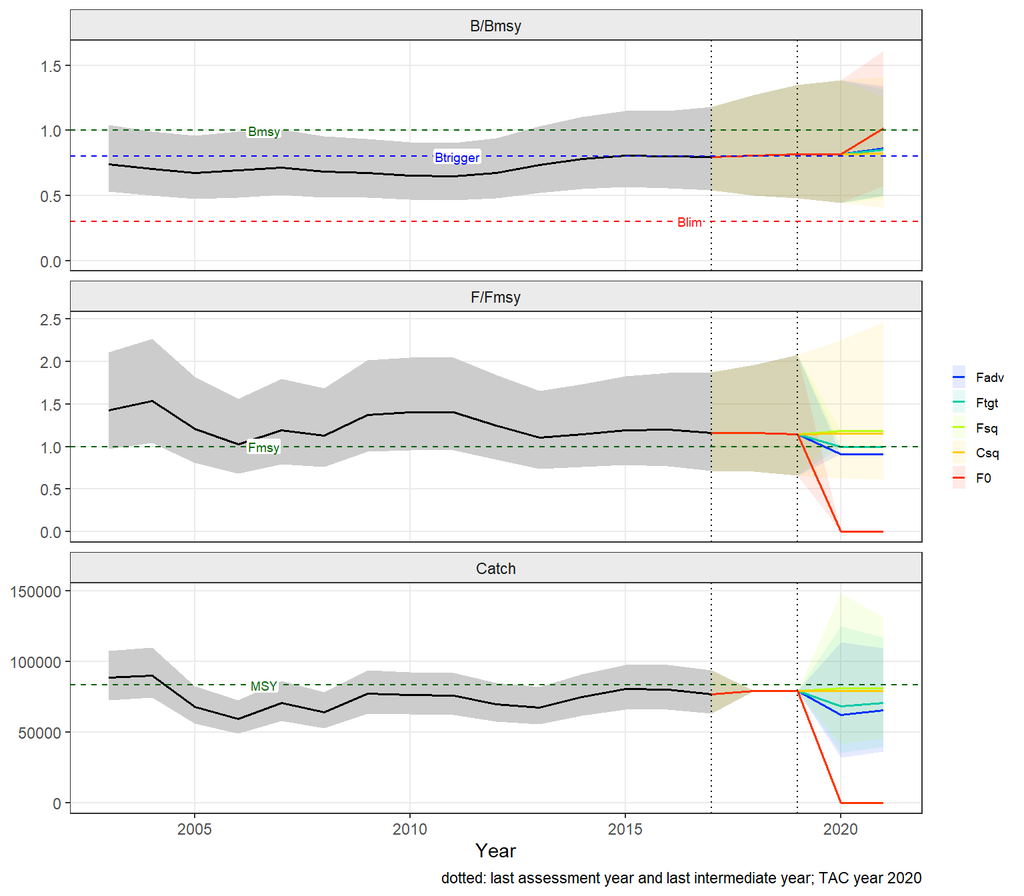

```r
fc <- list(Fadv = ctrl(hcr$Fadv, "Fmsy"), Ftgt = ctrl(1, "Fmsy"), Fsq = ctrl(fsq, "Fmsy"),
           Csq = ctrl(csq, "Catch"), F0 = ctrl(0, "Fmsy"))
stf <- jb3_fwd(fit, fc)
jbplot_projection(stf, bthr = c(Btrigger = bt))
```

`jb3_fwdtable()` summarises the fishing opportunities in the GFCM format (as `FLRef::fwd2type1()`): the catch and $F/F_{tgt}$ in the TAC year $y$, the biomass response at the start of the following year $y+1$ (start-of-year biomass, $B_{y+1} = B_y + P(B_y) - C_y$), its change relative to $B_{y-1}$, and the probabilities of being above $B_{lim}$, $B_{pa}$ (here $B_{trigger}$, `bthr`) and $B_{tgt}$:

```r
knitr::kable(jb3_fwdtable(stf, bthr = bt))
```

| Basis | C 2020 | F/Ftgt 2020 | B/Btgt 2021 | B change | P(B>Blim) | P(B>Bpa) | P(B>Btgt) |
| --- | --- | --- | --- | --- | --- | --- | --- |
| Fadv | 62366 | 0.909 | 0.866 | 6.1 | 99.8 | 61.8 | 29.2 |
| Ftgt | 68586 | 1.000 | 0.853 | 4.4 | 99.8 | 59.9 | 27.4 |
| Fsq | 81252 | 1.185 | 0.822 | 0.6 | 99.8 | 53.8 | 21.8 |
| Csq | 79021 | 1.152 | 0.823 | 0.8 | 99.5 | 54.3 | 28.6 |
| F0 | 0 | 0.000 | 1.015 | 24.3 | 99.9 | 80.8 | 51.8 |

Alternatively, `quant = "HCR"` applies the rule draw by draw in every projection year (`value` = $F_{tgt}$, rule settings in `hcr`), e.g. for a medium-term projection under the rule:

```r
hcr.ctrl <- data.frame(year = y0 + 1:10, value = c(csq, csq, rep(1, 8)),
                       quant = c("Catch", "Catch", rep("HCR", 8)))
pm <- jb3_fwd(fit, list(HCR = hcr.ctrl), hcr = list(btrigger = bt))
jbplot_projection(pm, bthr = c(Btrigger = bt))
```

For a weighted ensemble, pass a `jb3_ensemble()` instead of the single fit; the steps are the same.

Constant catch scenarios remain available, e.g. for TAC options:

```r
pc <- jb3_project(rec, catch = c(60000, 70000, 80000), nyears = 10)
knitr::kable(jb3_projtable(pc)[, 1:9])
```

| scenario | F/Fmsy | F | Catch 2018 | B/Bmsy 2018 | dB% 2018 | P(B>=Bmsy) 2018 | P(B<Blim) 2018 | P(F<=Fmsy) 2018 |
| --- | --- | --- | --- | --- | --- | --- | --- | --- |
| Catch = 60000 | 0.78 | 0.144 | 60000 | 0.8 | 2.26 | 0.28 | 0.002 | 0.712 |
| Catch = 70000 | 0.91 | 0.168 | 70000 | 0.8 | 2.26 | 0.28 | 0.002 | 0.581 |
| Catch = 80000 | 1.04 | 0.192 | 80000 | 0.8 | 2.26 | 0.28 | 0.002 | 0.458 |

# 15 Comparing runs and risk

## 15.1 Ensembles and sensitivity runs

`jbplot_ensemble()` compares a list of fits (scenarios, sensitivity runs, the steps of a workflow), as JABBA’s plot of the same name: trajectories coloured by run and a Kobe plot with each run’s terminal uncertainty and its median. With `joint = TRUE` the runs are pooled with equal weights into one ensemble.

```r
fsch <- jabba3(d, jb3_priors(d, r = c(0.2, 0.5)), jb3_model(shape = "schaefer"), osa = FALSE)
runs <- list(Fox = fit, Schaefer = fsch, `Lag + AR(1)` = rec)
```

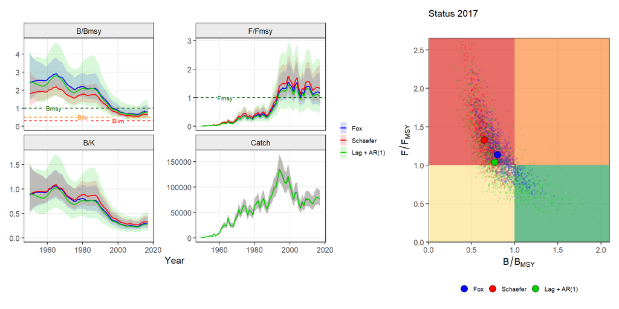

```r
jbplot_ensemble(runs)
```

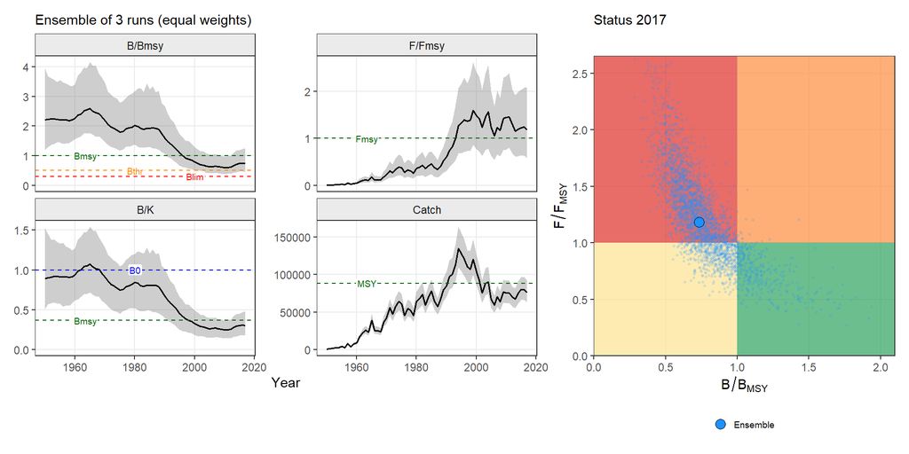

```r
jbplot_ensemble(runs, joint = TRUE)
```

`jbplot_summary()` gives the overview of JABBA’s `jbplot_summary()`: B, F, $B/B_{MSY}$, $F/F_{MSY}$ and $B/K$ by run, and the production curves with $B_{MSY}$ and MSY.

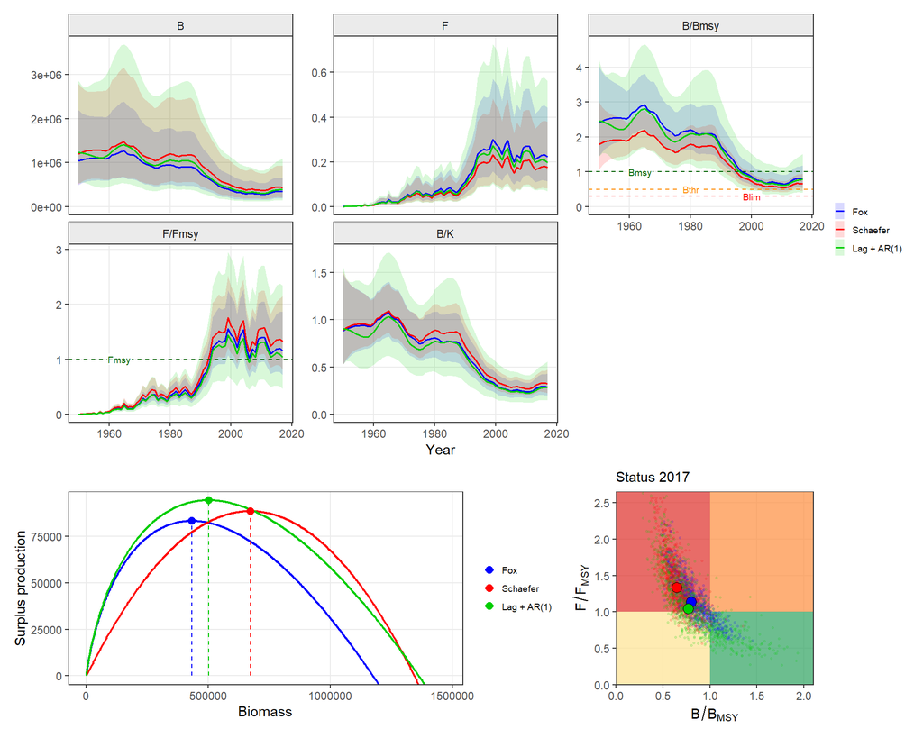

```r
jbplot_summary(runs)
```

### 15.1.1 Sensitivity runs with `update()`

A fit stores its data, priors, model and settings, so `update()` refits it with only the inputs that change. Priors and model options are changed by name, with the arguments of `jb3_priors()` and `jb3_model()`; all other inputs and settings (engine, draws, OSA, workflow) are taken from the fit. With `lapply()` a sensitivity analysis takes one line per factor:

```r
sens.r <- lapply(c(0.1, 0.2, 0.4), function(r)
  update(fit, priors = list(r = c(r, 0.5)), run = paste("r =", r)))
sens.sdb <- lapply(c(0.05, 0.1, 0.2), function(s)
  update(fit, priors = list(sdb = c(s, 0.3)), run = paste("sdb =", s)))
names(sens.r)   <- sapply(sens.r, `[[`, "run")
names(sens.sdb) <- sapply(sens.sdb, `[[`, "run")
t(sapply(c(sens.r, sens.sdb), function(f){
  s <- f$ts[f$ts$year == max(f$years) & f$ts$quantity %in% c("B/Bmsy", "F/Fmsy"), ]
  stats::setNames(round(s$est, 2), s$quantity) }))
```

```
#>            B/Bmsy F/Fmsy
#> r = 0.1      0.79   1.22
#> r = 0.2      0.80   1.16
#> r = 0.4      0.80   1.12
#> sdb = 0.05   0.73   1.30
#> sdb = 0.1    0.77   1.23
#> sdb = 0.2    0.80   1.16
```

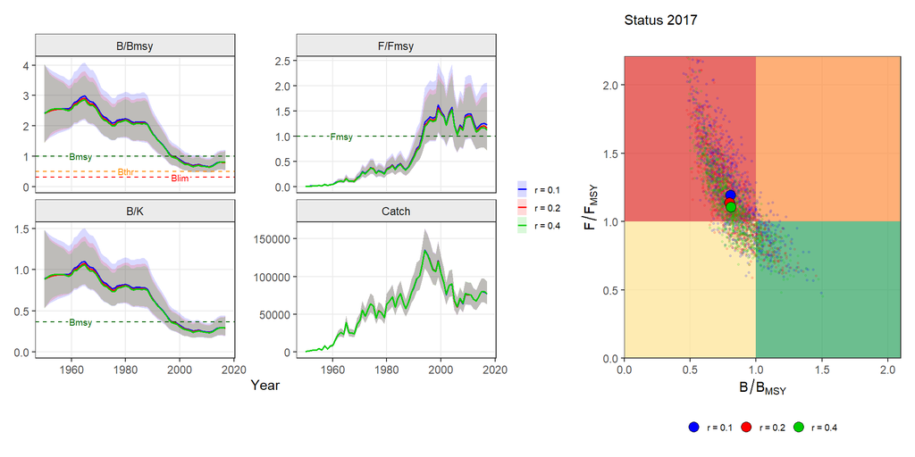

```r
jbplot_ensemble(sens.r)
```

Some priors are derived from others when `jb3_priors()` is called: the FishLife prior on the process-error SD (`sdb`) and the default `kdyn` from `r`, and the default `K` from the catch. By default `update()` changes only the priors that are named, so the `r` runs above keep the `sdb` prior of the base fit. Dependent priors can be set explicitly (`priors = list(r = c(0.4, 0.5), sdb = c(0.15, 0.3))`), or re-derived from the new values with `recompute = TRUE`:

```r
fr <- update(fit, priors = list(r = c(0.4, 0.5)), recompute = TRUE)
rbind(base = fit$priors$sdb, `r = 0.4` = sens.r[[3]]$priors$sdb, `r = 0.4, recompute` = fr$priors$sdb)
```

```
#>                       median log.sd on
#> base               0.1938757    0.3  1
#> r = 0.4            0.1938757    0.3  1
#> r = 0.4, recompute 0.2648421    0.3  1
```

The same works for model options, the workflow and the engine, e.g. a final NUTS run of the selected configuration:

```r
update(fit, model = list(lag = 3, rho = 0.75), run = "lag + AR(1)")   # model options
update(fit, workflow = "tier1", amat = 3)                             # rerun as a workflow
update(fit, engine = "nuts", nuts = list(iter = 2000))                # same inputs, NUTS
update(fit, data = d.new)                                             # new data, same settings
```

`kobe = FALSE` drops the Kobe panel in `jbplot_summary()` and `jbplot_ensemble()`. `jabbaplot3()` takes a list of runs too, with a choice of panels:

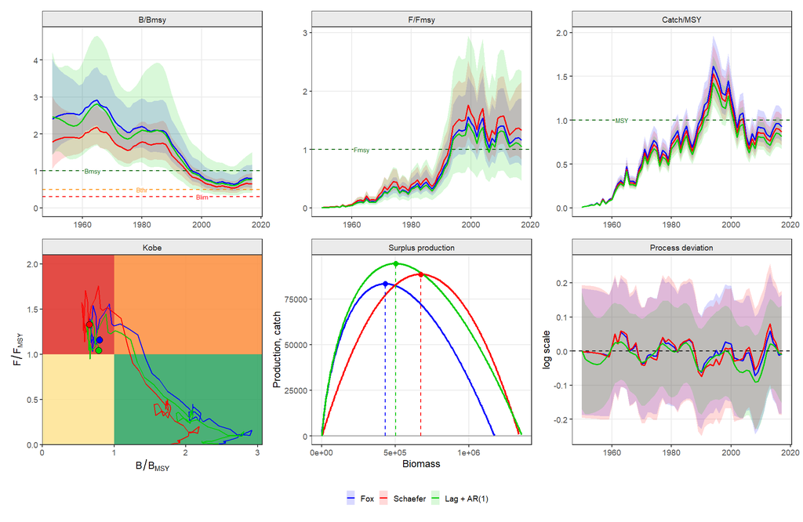

```r
jabbaplot3(runs, panels = c("B/Bmsy", "F/Fmsy", "Catch", "kobe", "production", "procdev"))
```

### 15.1.2 Weighted ensemble

`jb3_ensemble()` combines the runs into one weighted ensemble, as the GFCM/ICCAT JABBA ensembles: each run contributes a number of draws proportional to its weight, and the joint draws give the ensemble trajectories, reference points and status. `jb3_weights()` scores each run on diagnostics (convergence, runs tests, RMSE, and optionally hindcast MASE and Mohn’s rho with `hindcast` and `retro`); `weight = "equal"` gives equal weights:

```r
w <- jb3_weights(runs)
w
```

```
#>           run converged  runs rmse mase mohn score
#> 1         Fox      TRUE FALSE TRUE   NA   NA   0.5
#> 2    Schaefer      TRUE  TRUE TRUE   NA   NA   1.0
#> 3 Lag + AR(1)      TRUE FALSE TRUE   NA   NA   0.5
#>   weight
#> 1   0.25
#> 2   0.50
#> 3   0.25
```

```r
ens <- jb3_ensemble(runs, weights = w$weight)
ens
```

```
#> JABBA3 ensemble of 3 runs, 3000 draws
#>          run weight draws
#>          Fox   0.25   750
#>     Schaefer   0.50  1500
#>  Lag + AR(1)   0.25   750
#>   status 2017 : B/Bmsy 0.715  F/Fmsy 1.219
```

The ensemble behaves like a fit in the plots, tables and projections:

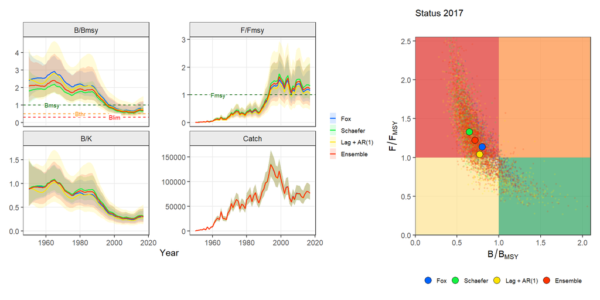

```r
jbplot_ensemble(ens)
```

### 15.1.3 Short-term advice with the HCR (GFCM)

`jb3_fwd()` and `jb3_hcr()` take the ensemble as they take a single fit (chapter *Projections*): each member’s own model (production function, lag, AR(1) process error) is projected on its share of the draws, so the forecast carries the structural uncertainty between the runs. As in the GFCM Type 1 management procedure: two intermediate years at the status quo catch, the hockey-stick rule ($B_{trigger} = B_{thr} = 0.5 B_{MSY}$) applied to the ensemble $B/B_{MSY}$ in the TAC year, and the fishing opportunities for $F_{adv}$, $F_{tgt}$, $F_{sq}$, $C_{sq}$ and $F = 0$:

```r
y0  <- max(ens$years)
yrs <- y0 + 1:4
csq <- mean(tail(fit$data$catch, 3))
fsq <- mean(tail(ens$ts$est[ens$ts$quantity == "F/Fmsy"], 3))
ctrl <- function(v, q) data.frame(year = yrs, value = c(csq, csq, v, v), quant = c("Catch", "Catch", q, q))
hcr.ens <- jb3_hcr(jb3_fwd(ens, list(Ftgt = ctrl(1, "Fmsy"))), ftgt = 1, btrigger = 0.5, blim = 0.3)
hcr.ens
```

```
#> Hockey-stick HCR (Ftgt 1.00 Fmsy, Btrigger 0.50 Bmsy) in 2020: B/Bmsy median 0.740, P(B < Btrigger) 0.15
#>   F_adv/Fmsy: 1.000 (median B), 0.972 (precautionary, across draws) -> 0.972
```

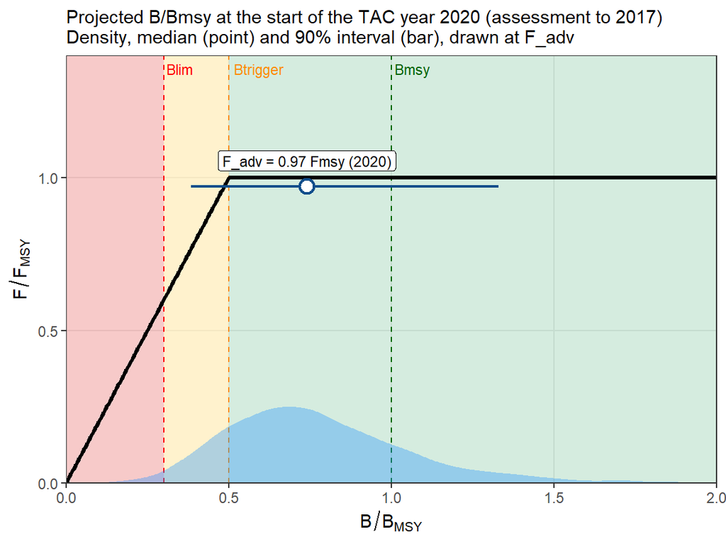

```r
jbplot_hcr(hcr.ens)
```

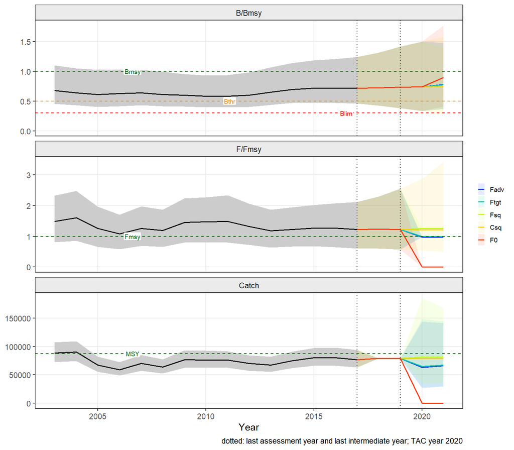

```r
fc.ens <- list(Fadv = ctrl(hcr.ens$Fadv, "Fmsy"), Ftgt = ctrl(1, "Fmsy"), Fsq = ctrl(fsq, "Fmsy"),
               Csq = ctrl(csq, "Catch"), F0 = ctrl(0, "Fmsy"))
stf.ens <- jb3_fwd(ens, fc.ens)
jbplot_projection(stf.ens)
```

The fishing opportunities table gives the catch and F in the TAC year $y$ and the biomass response at the start of the following year $y+1$ (`osa = TRUE`, the default): the biomass is the start-of-year biomass, $B_{y+1} = B_y + P(B_y) - C_y$, so the effect of the TAC in $y$ appears in $B_{y+1}$. The change in biomass is $B_{y+1}$ relative to $B_{y-1}$, the start of the last intermediate year, as in `FLRef::fwd2type1()`:

```r
knitr::kable(jb3_fwdtable(stf.ens))
```

| Basis | C 2020 | F/Ftgt 2020 | B/Btgt 2021 | B change | P(B>Blim) | P(B>Bpa) | P(B>Btgt) |
| --- | --- | --- | --- | --- | --- | --- | --- |
| Fadv | 63215 | 0.972 | 0.776 | 6.0 | 99.0 | 88.9 | 20.3 |
| Ftgt | 65050 | 1.000 | 0.772 | 5.5 | 99.0 | 88.7 | 19.8 |
| Fsq | 81392 | 1.251 | 0.740 | 1.2 | 98.9 | 87.1 | 15.7 |
| Csq | 79021 | 1.215 | 0.747 | 2.1 | 97.0 | 81.9 | 21.4 |
| F0 | 0 | 0.000 | 0.897 | 22.6 | 99.5 | 93.4 | 37.7 |

### 15.1.4 Long-term TAC projections

For the medium- to long-term consequences of TAC levels, catch scenarios as multiples of the current catch (`Csq`, mean of the last three years), with three intermediate years at the current catch and a horizon of about two generation times:

```r
cr <- seq(0, 1.6, 0.2)
prjens <- jb3_project(ens, scenarios = setNames(lapply(cr, function(m) c(Csq = m)), paste0(100*cr, "% Csq")),
                      nyears = 31, imp.years = 3)
```

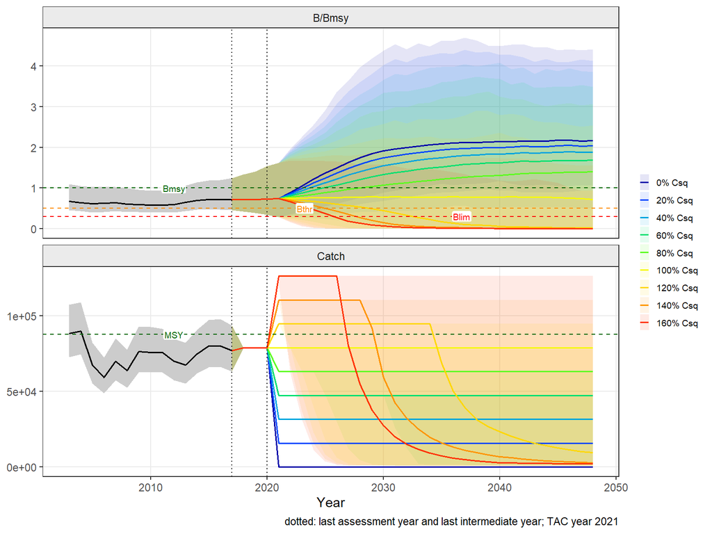

```r
jbplot_projection(prjens, type = c("B/Bmsy", "Catch"))
```

Catches above the surplus production deplete the stock in the long term; the projected catch is capped at 95% of the biomass, so the catch falls once the stock is depleted. The Kobe matrices take the ensemble projection in the same way as a single fit, e.g. `jb3_kobematrix(prjens, what = "all", percent = TRUE)`.

## 15.2 Risk curves

`jbplot_crisk()` plots, as JABBA’s `jbplot_Crisk()`, the probability that $B < B_{MSY}$, that $F > F_{MSY}$ and that $B < 0.5 B_{MSY}$ (`bfrac`) against the scenario value (catch or F/F<sub>MSY</sub>), one line per projection year. It takes any projection with several catch or F scenarios, of a single fit (e.g. `jbplot_crisk(pj)` for the F/F<sub>MSY</sub> scenarios of the chapter *Projections*) or of an ensemble. The catch level at which a risk curve crosses a chosen probability (e.g. 0.5, or a lower risk tolerance) in a given year is the corresponding catch advice.

### 15.2.1 U.S. advice: risk plots with MSST

Risk plots of this kind support U.S. advice (NOAA, SEDAR assessments), where the biomass limit is the minimum stock size threshold, e.g. $MSST = (1 - M) B_{MSY}$ as in the JABBA assessment of great hammerhead for SEDAR 77 (SEDAR 2024). A named `bfrac` labels the panel, and `x = "ratio"` shows the catch relative to the current catch, as `type = "ratio"` in JABBA’s `fw_jabba()`. For the ensemble projection:

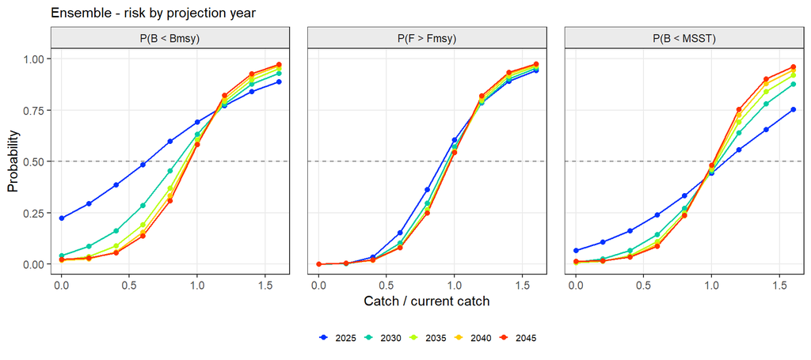

```r
M <- 0.3                                          # natural mortality (illustrative)
jbplot_crisk(prjens, years = seq(2025, 2045, 5), bfrac = c(MSST = 1 - M), x = "ratio")
```

MSST can also be drawn on the projection plot, `jbplot_projection(prjens, bthr = c(MSST = 1 - M), blim = NULL)`.

# 16 The rebuilding protocol: Atlantic blue marlin

Bigeye tuna is the standard example of this guide. This chapter is the more complex one: it introduces the BioProcDyn rebuilding protocol on a stock where it matters. The 2018 ICCAT assessment of Atlantic blue marlin (*Makaira nigricans*) used JABBA and Stock Synthesis (SS3), and the two differed markedly in how fast the stock was projected to rebuild. This chapter reproduces the 2018 JABBA base case, applies the BioProcDyn protocol step by step (life-history process error prior, production lag, persistent AR(1) process error) and compares status, diagnostics and forecasts.

## 16.1 The 2018 base case

The 2018 base case was a Pella-Tomlinson model with $B_{MSY}/K = 0.36$, an r prior of 0.098 (CV 0.18), an uninformative K prior, initial depletion near unfished, ten CPUE indices with an additional observation error of 0.25, and the process error fixed at $\sigma = 0.07$ and process deviations starting with the first index year. In JABBA3 (the additional observation variance is estimated by index):

```r
bum <- iccat$bum
d.bum  <- jb3_data(bum$catch, bum$cpue, bum$se, stock = "bum")
pr.bum <- jb3_priors(d.bum, r = c(0.098, 0.18), K = c(50000, sqrt(log(1 + 2^2))),
                     bkinit = c(1, sqrt(log(1 + 0.25^2))))
m.base <- jb3_model(shape = "pella", BmsyK = 0.36, sdb.fixed = 0.07, start = "index")
bum.base <- jabba3(d.bum, pr.bum, m.base, run = "2018 base")
bum.base
```

```
#> JABBA3 fit: 2018 base ( bum )  engine: rtmb
#>   model: pella
#>   convergence: ok (max gradient 1.3e-09, Newton decrement 1.0e-20)
#>   estimates (mode, 95% CI):
#>             est      lci      uci
#> K      9.15e+04 6.83e+04 1.22e+05
#> r      9.47e-02 6.99e-02 1.28e-01
#> bkinit 1.22e+00 1.11e+00 1.35e+00
#> sdb    7.00e-02       NA       NA
#> q1     1.58e-05 1.13e-05 2.21e-05
#> q2     1.60e-05 1.03e-05 2.48e-05
#> q3     3.07e-05 2.11e-05 4.45e-05
#> q4     3.43e-05 2.31e-05 5.09e-05
#> q5     2.57e-05 1.63e-05 4.07e-05
#> q6     2.91e-05 1.79e-05 4.73e-05
#> q7     1.55e-05 1.03e-05 2.33e-05
#> q8     2.54e-05 1.74e-05 3.72e-05
#> q9     3.42e-05 2.24e-05 5.23e-05
#> q10    2.43e-05 1.14e-05 5.16e-05
#> sdi1   1.20e-01 7.17e-02 2.00e-01
#> sdi2   6.65e-01 4.82e-01 9.17e-01
#> sdi3   1.86e-01 9.70e-02 3.56e-01
#> sdi4   2.10e-01 1.29e-01 3.43e-01
#> sdi5   2.12e-01 5.04e-02 8.92e-01
#> sdi6   6.46e-01 4.60e-01 9.08e-01
#> sdi7   6.55e-01 4.94e-01 8.67e-01
#> sdi8   4.04e-01 2.88e-01 5.68e-01
#> sdi9   1.61e-01 1.81e-02 1.42e+00
#> sdi10  9.92e-01 8.20e-01 1.20e+00
#> m      9.58e-01       NA       NA
#> Bmsy   3.29e+04 2.46e+04 4.41e+04
#> Fmsy   9.89e-02 7.30e-02 1.34e-01
#> MSY    3.25e+03 2.70e+03 3.93e+03
#>   status 2016: B/Bmsy 0.78 (0.55-1.13), F/Fmsy 0.80 (0.49-1.29)
```

The same fit follows from the original JABBA input with the converter (`jbinput2jabba3()`, chapter *Converting from JABBA and SPiCT*):

```r
jb.bum <- JABBA::build_jabba(catch = bum$catch, cpue = bum$cpue, se = bum$se,
  assessment = "BUM", scenario = "2018 base", model.type = "Pella", BmsyK = 0.36,
  K.prior = c(50000, 2), r.prior = c(0.098, 0.18), psi.prior = c(1, 0.25),
  fixed.obsE = 0.25, proc.dev.all = FALSE, sigma.proc = 0.07, verbose = FALSE)
x.bum <- jbinput2jabba3(jb.bum, keep.igamma = TRUE)
bum.base <- jabba3(x.bum$data, x.bum$priors, x.bum$model, run = "2018 base")
```

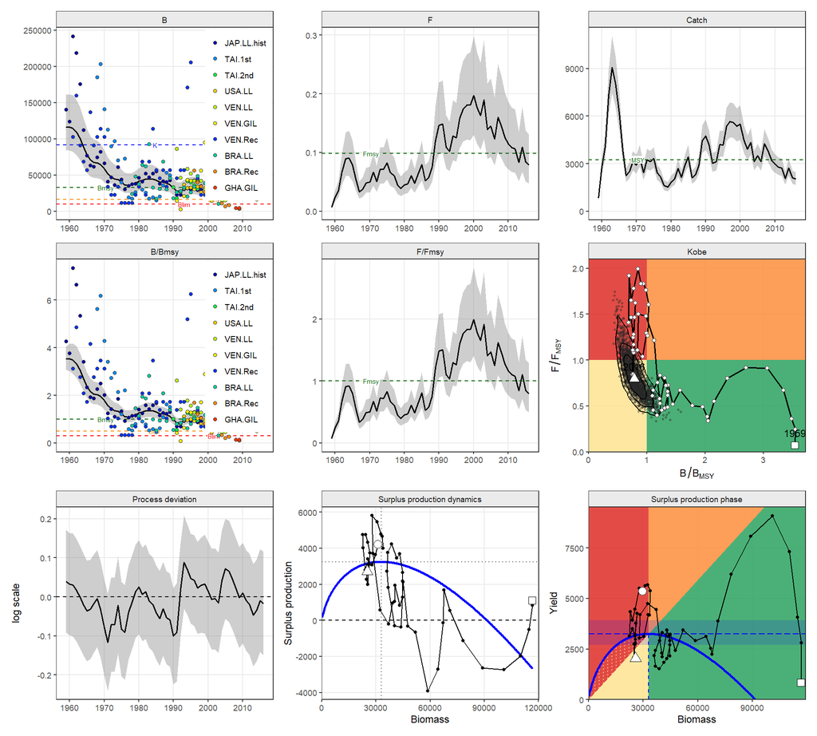

```r
plot(bum.base)
```

The fit is close to the 2018 JAGS assessment. Note the process deviations: with $\sigma$ fixed at a low value they form long runs of the same sign, a lag-1 autocorrelation of

```r
pd <- bum.base$ts$est[bum.base$ts$quantity == "Process deviation"]
round(acf(pd, plot = FALSE)$acf[2], 2)
```

```
#> [1] 0.78
```

This is the persistence that the BioProcDyn simulations identify as the source of rebuilding optimism: a model with independent process error absorbs the persistent part of the production anomalies into r and K.

## 16.2 Joint versus separate indices

Chapter *Data exploration* combined the ten indices into one joint index (`bum.joint`) and found some conflicts among them. Does it matter for the assessment whether the production model is fitted to the ten separate indices or to the joint index? Same priors and settings, the joint index with its own log-scale SE:

```r
if(!exists("bum.joint")) bum.joint <- jb3_jointindex(jb3_trend(bum$cpue, bum$se))
d.joint  <- jb3_data(bum$catch, bum.joint, stock = "bum")
pr.joint <- jb3_priors(d.joint, r = c(0.098, 0.18), K = c(50000, sqrt(log(1 + 2^2))),
                       bkinit = c(1, sqrt(log(1 + 0.25^2))))
bum.ji <- jabba3(d.joint, pr.joint, m.base, run = "joint index")
bum.js <- list(`10 indices` = bum.base, `joint index` = bum.ji)
pt <- jb3_partable(bum.js, format = "wide")
knitr::kable(pt[pt$Parameter %in% c("K", "r", "MSY", "B/Bmsy", "F/Fmsy"), ], row.names = FALSE)
```

| Parameter | 10 indices | joint index |
| --- | --- | --- |
| K | 91,500 (68,300-122,000) | 93,100 (69,400-125,000) |
| r | 0.0947 (0.0699-0.128) | 0.0935 (0.069-0.127) |
| MSY | 3,250 (2,700-3,930) | 3,270 (2,710-3,960) |
| B/Bmsy | 0.784 (0.545-1.13) | 0.775 (0.572-1.05) |
| F/Fmsy | 0.798 (0.494-1.29) | 0.803 (0.52-1.24) |

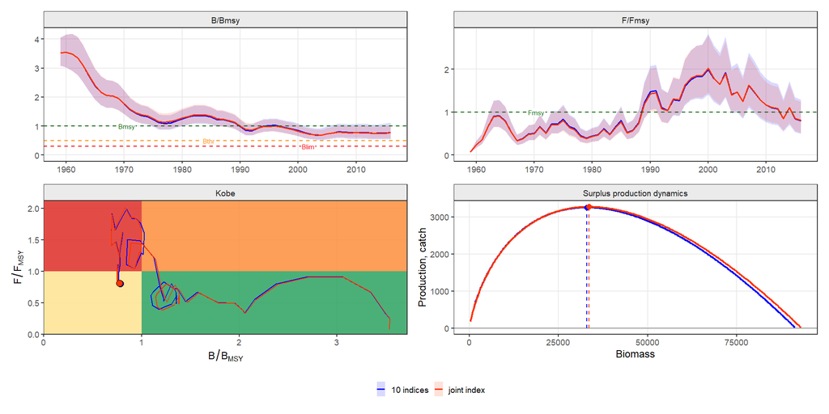

```r
jabbaplot3(bum.js, panels = c("B/Bmsy", "F/Fmsy", "kobe", "spdyn"))
```

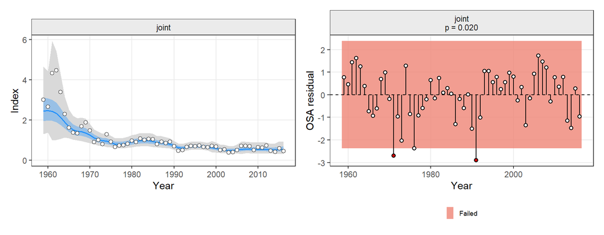

```r
patchwork::wrap_plots(jbplot_fits(bum.ji), jbplot_runs(bum.ji), ncol = 2)
```

```r
dg <- lapply(bum.js, jb3_diags)
knitr::kable(do.call(rbind, lapply(names(dg), function(n) data.frame(run = n, dg[[n]][, c("index", "n", "RMSE", "SDNR", "runs.p", "flag")]))),
             digits = 3, row.names = FALSE, caption = "Residual diagnostics (OSA residuals) by index")
```

Residual diagnostics (OSA residuals) by index

| run | index | n | RMSE | SDNR | runs.p | flag |
| --- | --- | --- | --- | --- | --- | --- |
| 10 indices | JAP.LL.hist | 40 | 0.226 | 1.108 | 0.100 | FALSE |
| 10 indices | VEN.Rec | 40 | 0.718 | 1.008 | 0.002 | TRUE |
| 10 indices | TAI.1st | 22 | 0.684 | 0.991 | 0.001 | TRUE |
| 10 indices | BRA.LL | 28 | 0.453 | 1.053 | 0.389 | FALSE |
| 10 indices | TAI.2nd | 8 | 0.190 | 1.151 | 0.015 | TRUE |
| 10 indices | VEN.LL | 19 | 0.444 | 0.663 | 0.002 | TRUE |
| 10 indices | VEN.GIL | 22 | 0.620 | 0.910 | 0.391 | TRUE |
| 10 indices | USA.LL | 24 | 0.240 | 1.026 | 0.500 | FALSE |
| 10 indices | BRA.Rec | 19 | 0.692 | 1.130 | 0.598 | FALSE |
| 10 indices | GHA.GIL | 10 | 1.055 | 1.074 | 0.004 | TRUE |
| joint index | joint | 58 | 0.199 | 1.087 | 0.020 | TRUE |

Status, reference points and productivity are practically the same: $B/B_{MSY}$ in 2016 of about 0.78 and $F/F_{MSY}$ of 0.80 with either input, and the joint index gives a slightly narrower interval for $B/B_{MSY}$. The ten indices carry one common signal, and the production model extracts the same signal from the joint index. The separate fit flags six of the ten indices on their residual diagnostics; the joint index has a small RMSE (0.20) but its OSA residuals still fail the runs test (p = 0.02), which reflects the low fixed process error of the base case rather than conflict among indices.

The rest of this chapter continues with the ten separate indices, as in the 2018 assessment: each index keeps its own catchability and observation variance, and the diagnostics can still point to individual series. The joint index is a useful check on the combined signal and a simpler alternative where the separate indices are numerous and short.

## 16.3 Applying the protocol

Three steps, each added to the previous one:

1. **Life-history prior on the process error scale** (the JABBA3 default, $\sigma_{MSY} = 0.80 \sigma_R r^{0.45}$) instead of the fixed $\sigma = 0.07$;
2. **production lag** at the age at maturity (here 3 years);
3. **AR(1) process deviations** with $\rho = 0.75$ (the default; blue marlin falls in the 6-10 year generation-time class of `jb3_rho_table()`).

```r
# pr.bum already carries the life-history sdb prior (default); the base case fixed sdb in the model
mod <- function(lag = 0, rho = 0) jb3_model(shape = "pella", BmsyK = 0.36, start = "index", lag = lag, rho = rho)
bum.runs <- list(
  `2018 base`     = bum.base,
  `sdb prior`     = jabba3(d.bum, pr.bum, mod(),        run = "sdb prior"),
  `+ lag`         = jabba3(d.bum, pr.bum, mod(3),       run = "+ lag"),
  `+ lag + AR(1)` = jabba3(d.bum, pr.bum, mod(3, 0.75), run = "+ lag + AR(1)"))
pt <- jb3_partable(bum.runs, format = "wide")
knitr::kable(pt[pt$Parameter %in% c("K", "r", "Bmsy", "Fmsy", "MSY", "sigma.proc", "rho", "B/Bmsy", "F/Fmsy"), ], row.names = FALSE)
```

| Parameter | 2018 base | sdb prior | + lag | + lag + AR(1) |
| --- | --- | --- | --- | --- |
| K | 91,500 (68,300-122,000) | 93,800 (64,100-137,000) | 96,300 (66,400-140,000) | 98,600 (58,000-168,000) |
| r | 0.0947 (0.0699-0.128) | 0.0982 (0.0707-0.137) | 0.0972 (0.0706-0.134) | 0.104 (0.0738-0.146) |
| Bmsy | 32,900 (24,600-44,100) | 33,800 (23,100-49,500) | 34,700 (23,900-50,300) | 35,500 (20,900-60,300) |
| Fmsy | 0.0989 (0.073-0.134) | 0.103 (0.0738-0.143) | 0.101 (0.0737-0.14) | 0.108 (0.077-0.153) |
| MSY | 3,250 (2,700-3,930) | 3,460 (2,590-4,630) | 3,520 (2,650-4,670) | 3,850 (2,400-6,180) |
| sigma.proc | 0.07 | 0.14 (0.102-0.192) | 0.138 ( 0.1-0.191) | 0.117 (0.0762-0.18) |
| rho | 0 | 0 | 0 | 0.75 |
| B/Bmsy | 0.784 (0.545-1.13) | 0.605 (0.403-0.907) | 0.581 (0.376-0.897) | 0.409 (0.209-0.801) |
| F/Fmsy | 0.798 (0.494-1.29) | 0.971 (0.563-1.68) | 0.996 (0.573-1.73) | 1.29 (0.654-2.55) |

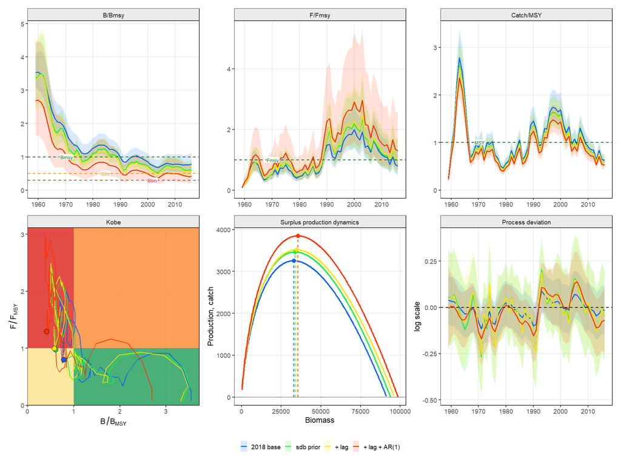

```r
jabbaplot3(bum.runs, panels = c("B/Bmsy", "F/Fmsy", "Catch", "kobe", "spdyn", "procdev"))
```

## 16.4 Diagnostics

Retrospective patterns and index prediction skill do not distinguish the runs; both are acceptable in all of them. As in the simulations, the standard diagnostics cannot tell whether a model is optimistic about rebuilding.

```r
bum.hc <- lapply(bum.runs, jb3_hindcast, n = 5)
bum.rt <- lapply(bum.runs, jb3_retro, n = 5)
mase <- sapply(bum.hc, function(h){ m <- h$mase; stats::setNames(m$MASE, m$index)[is.finite(m$MASE)] })
mohn <- sapply(bum.rt, function(r) stats::setNames(r$rho$rho, r$rho$quantity))
knitr::kable(round(rbind(mase, mohn[c("B/Bmsy", "F/Fmsy"), , drop = FALSE]), 2),
             caption = "Hindcast MASE by index and Mohn's rho")
```

Hindcast MASE by index and Mohn’s rho

|  | 2018 base | sdb prior | + lag | + lag + AR(1) |
| --- | --- | --- | --- | --- |
| BRA.Rec | 0.56 | 0.57 | 0.57 | 0.58 |
| USA.LL | 0.87 | 0.90 | 0.89 | 0.94 |
| VEN.GIL | 0.40 | 0.20 | 0.20 | 0.08 |
| B/Bmsy | 0.09 | 0.08 | 0.08 | 0.07 |
| F/Fmsy | -0.11 | -0.10 | -0.10 | -0.08 |

Hindcasts for the two indices that extend to the end of the series and dominate the recent trend (US and Brazilian recreational/longline CPUE), for the 2018 base case and the protocol:

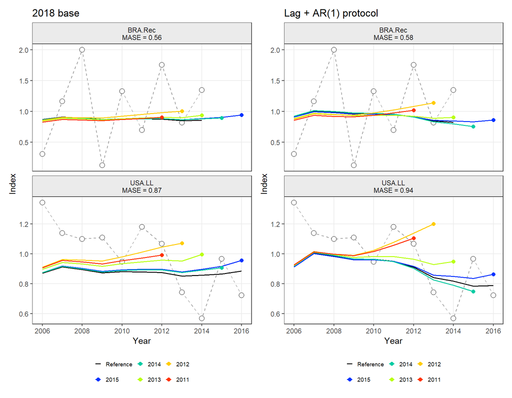

```r
patchwork::wrap_plots(
  jbplot_hcxval(bum.hc$`2018 base`, indices = c("USA.LL", "BRA.Rec"), ncol = 1) + ggplot2::ggtitle("2018 base"),
  jbplot_hcxval(bum.hc$`+ lag + AR(1)`, indices = c("USA.LL", "BRA.Rec"), ncol = 1) + ggplot2::ggtitle("Lag + AR(1) protocol"),
  ncol = 2)
```

## 16.5 Forecasts

The runs differ most in their forecasts. Constant-catch projections of 1500, 2000 and 2500 t, with the AR(1) process continued from the last estimated deviation in the persistent model:

```r
bum.pc <- lapply(bum.runs[c("2018 base", "+ lag + AR(1)")], jb3_project,
                 catch = c(1500, 2000, 2500), nyears = 10)
lapply(bum.pc, function(p) knitr::kable(jb3_kobematrix(p)[, c(1, 2, 4, 6, 11)],
       caption = "P(green) by year"))
```

```
#> $`2018 base`
#>
#>
#> Table: P(green) by year
#>
#> |  TAC| 2017| 2019| 2021| 2026|
#> |----:|----:|----:|----:|----:|
#> | 1500| 0.13| 0.33| 0.55| 0.86|
#> | 2000| 0.13| 0.28| 0.43| 0.71|
#> | 2500| 0.13| 0.24| 0.33| 0.50|
#>
#> $`+ lag + AR(1)`
#>
#>
#> Table: P(green) by year
#>
#> |  TAC| 2017| 2019| 2021| 2026|
#> |----:|----:|----:|----:|----:|
#> | 1500| 0.01| 0.05| 0.14| 0.37|
#> | 2000| 0.01| 0.05| 0.11| 0.29|
#> | 2500| 0.01| 0.04| 0.09| 0.21|
```

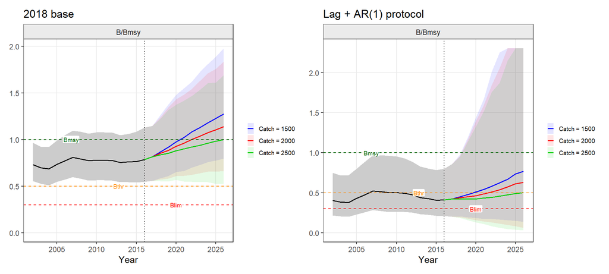

```r
patchwork::wrap_plots(
  jbplot_projection(bum.pc$`2018 base`, type = "B/Bmsy") + ggplot2::ggtitle("2018 base"),
  jbplot_projection(bum.pc$`+ lag + AR(1)`, type = "B/Bmsy") + ggplot2::ggtitle("Lag + AR(1) protocol"))
```

# 17 Other data features

The data-exploration chapter looked at index trends, catchabilities and conflicts among indices of one stock. This chapter covers other common data situations, with two anonymised example datasets:

```r
data(jara_examples)
names(jara_examples)
```

```
#> [1] "areas"   "regions"
```

```r
names(jara_examples$areas)
```

```
#> [1] "catch"  "idx"    "idx.se" "bio"    "bio.se"
```

```r
names(jara_examples$regions)
```

```
#>  [1] "year"      "areaA"     "areaB"     "C.survey1"
#>  [5] "C.survey2" "C.cpue1"   "C.cpue2"   "C.cpue3"
#>  [9] "C.cpue4"   "C.cpue5"
```

- `areas`: a catch history from six fleets or areas, two of them with missing early years; relative survey indices with log-SEs for four areas; and swept-area survey biomass for the same four areas;
- `regions`: indices from three regions, a survey each in two adjacent areas (`areaA`, `areaB`) and two surveys and five CPUE series in a third region (`C.*`).

## 17.1 Catch history with missing years

Two fleets report only in the later years (`fleet4`, `fleet5`):

```r
cc <- jara_examples$areas$catch
colSums(!is.na(cc[, -1]))
```

```
#> fleet1 fleet2 fleet3 fleet4 fleet5 fleet6
#>     19     21     24     10     10     26
```

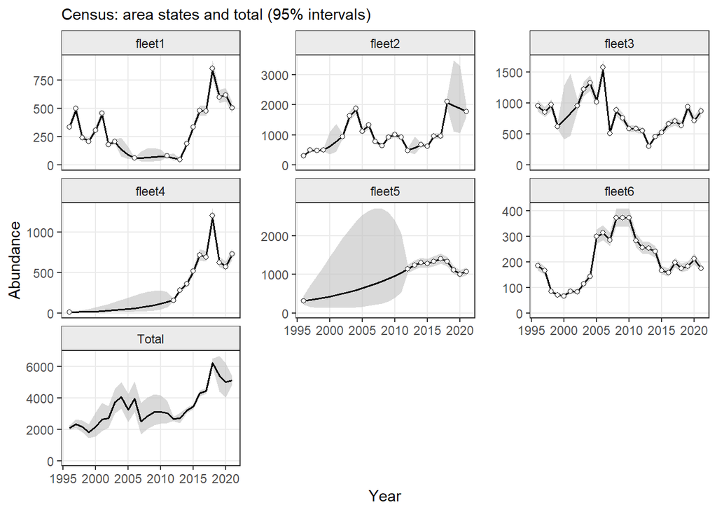

```r
cc[1, "fleet5"] <- cc[1, "fleet2"]; cc[1, "fleet4"] <- 10
sc <- cc; sc[, -1] <- 0.05; sc[1, c("fleet4", "fleet5")] <- 0.2
cf <- jb3_catchfill(cc, se = sc, timeblock = 2016)
jbplot_trend(attr(cf, "fit"))          # fleet fits and the total
```

The total catch with its year-specific log-SE, larger where fleets with assumed start values are interpolated:

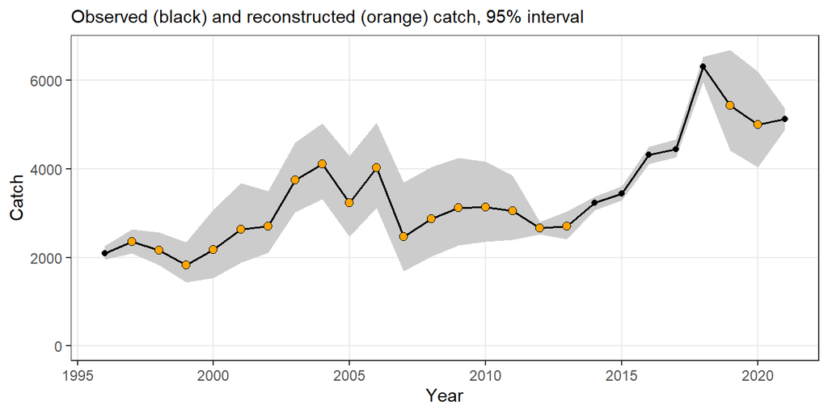

```r
jbplot_catchfill(cf)
```

```r
knitr::kable(as.data.frame(cf)[c(1:3, 15:18, 24:26), c("year", "catch", "se.log", "lci", "uci")],
             digits = 3, row.names = FALSE)
```

| year | catch | se.log | lci | uci |
| --- | --- | --- | --- | --- |
| 1996 | 2097.300 | 0.039 | 1947.461 | 2266.393 |
| 1997 | 2360.185 | 0.060 | 2086.894 | 2639.184 |
| 1998 | 2167.053 | 0.087 | 1822.092 | 2561.615 |
| 2010 | 3137.244 | 0.146 | 2354.137 | 4171.678 |
| 2011 | 3051.221 | 0.120 | 2403.248 | 3850.117 |
| 2012 | 2659.563 | 0.026 | 2528.645 | 2805.143 |
| 2013 | 2707.469 | 0.058 | 2418.475 | 3041.539 |
| 2019 | 5436.590 | 0.106 | 4420.018 | 6690.056 |
| 2020 | 5000.580 | 0.109 | 4047.269 | 6201.394 |
| 2021 | 5123.100 | 0.024 | 4893.222 | 5366.658 |

The filled table, with the original series, the missing values replaced by predictions, and the total:

```r
knitr::kable(head(jb3_fill_table(cf, digits = 1), 6), row.names = FALSE)
```

| year | fleet1 | fleet2 | fleet3 | fleet4 | fleet5 | fleet6 | Total |
| --- | --- | --- | --- | --- | --- | --- | --- |
| 1996 | 334.2 | 307.5 | 954.0 | 10.0 | 307.5 | 184.1 | 2097.3 |
| 1997 | 498.3 | 496.9 | 852.7 | 11.7 | 334.5 | 166.0 | 2360.2 |
| 1998 | 240.6 | 492.8 | 972.1 | 14.0 | 363.0 | 84.6 | 2167.1 |
| 1999 | 210.7 | 508.8 | 626.3 | 16.6 | 393.8 | 70.6 | 1826.9 |
| 2000 | 308.0 | 629.9 | 727.9 | 19.8 | 427.3 | 66.4 | 2179.3 |
| 2001 | 457.3 | 776.9 | 836.5 | 23.5 | 463.6 | 85.1 | 2643.0 |

The reconstructed catch goes into `jb3_data()` with its year-specific SE, which the catch error of the model uses in place of the constant `sdc`; the `jb3catchfill` object can be passed directly as the catch:

```r
d.cf <- jb3_data(cf, jara_examples$areas$idx, jara_examples$areas$idx.se, stock = "areas")
round(range(d.cf$catch.se), 3)
```

```
#> [1] 0.022 0.200
```

## 17.2 Swept-area surveys in several areas

A survey covering four areas gives two kinds of index: relative indices by area (`idx`, with log-SEs) and swept-area biomass estimates (`bio`). The relative indices are combined into a joint index as in the data-exploration chapter:

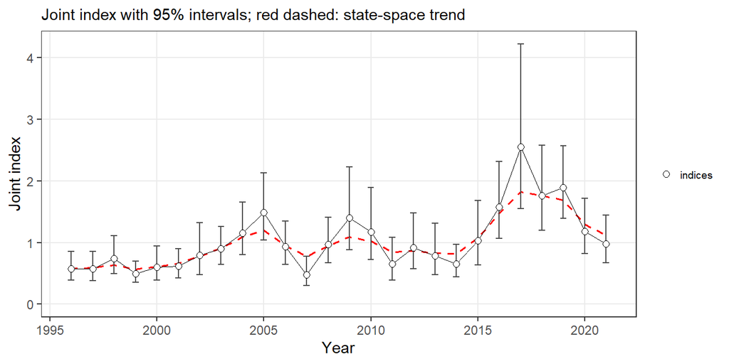

```r
a <- jara_examples$areas
ji.a <- jb3_trend(a$idx, a$idx.se, run = "relative")
jdx.a <- jb3_jointindex(ji.a)
jbplot_jointindex(ji.a)
```

The swept-area estimates are absolute and additive over areas, so a census model fits each area separately and sums the area states to a total biomass with uncertainty, smoothing through years with missing surveys:

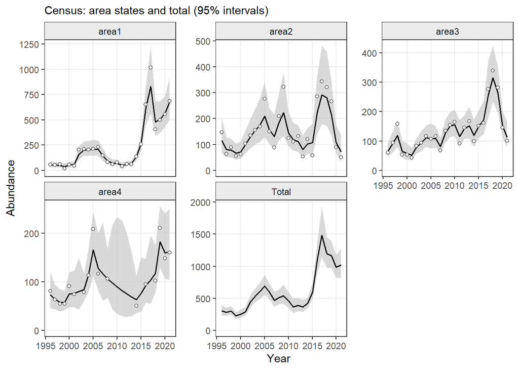

```r
bi <- jb3_trend(a$bio, a$bio.se, type = "census", run = "swept-area census")
jbplot_trend(bi)
```

The census total and the relative joint index, both scaled to their means:

```r
tb <- bi$total
sc1 <- mean(jdx.a$index, na.rm = TRUE); sc2 <- mean(tb$est)
cmp2 <- rbind(data.frame(year = jdx.a$year, index = jdx.a$index/sc1, lci = jdx.a$lci/sc1, uci = jdx.a$uci/sc1,
                         series = "relative joint index"),
              data.frame(year = tb$year, index = tb$est/sc2, lci = tb$lci/sc2, uci = tb$uci/sc2,
                         series = "census total biomass"))
round(cor(log(jdx.a$index), log(tb$est[match(jdx.a$year, tb$year)]), use = "complete.obs"), 2)
```

```
#> [1] 0.87
```

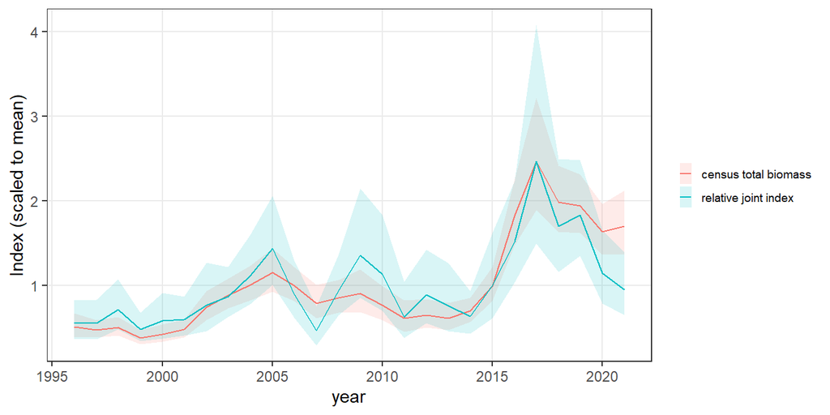

```r
ggplot2::ggplot(cmp2, ggplot2::aes(year, index, colour = series, fill = series)) +
  ggplot2::geom_ribbon(ggplot2::aes(ymin = lci, ymax = uci), alpha = 0.15, colour = NA) + ggplot2::geom_line() +
  ggplot2::labs(y = "Index (scaled to mean)", colour = NULL, fill = NULL) + theme_jabba3()
```

The two agree closely. They answer different questions, however: the joint index weights areas by the precision of their indices, the census total by their biomass, so an area with much of the biomass but a noisy index counts more in the census. Where the trends differ, the census total is the better measure of the whole stock; it can also go into the production model as an index of its own, with the log-SE of the census total.

## 17.3 Do indices among areas conflict? Stock structure

When indices come from several regions, the question is whether they follow a common trend, in which case the regions can be assessed together, or diverge, which may point to separate stocks or at least to regions with different dynamics. The `regions` data have surveys of two adjacent areas and seven indices of a third region C:

```r
rg <- jara_examples$regions
colSums(!is.na(rg[, -1]))
```

```
#>     areaA     areaB C.survey1 C.survey2   C.cpue1
#>        33        24        28        21        32
#>   C.cpue2   C.cpue3   C.cpue4   C.cpue5
#>        14        18        26         6
```

**Within regions.** First the joint index of each region: A and B together (adjacent areas), and C:

```r
tr.AB <- jb3_trend(rg[, c("year", "areaA", "areaB")], run = "A + B")
tr.C  <- jb3_trend(rg[, c("year", grep("^C\\.", names(rg), value = TRUE))], run = "C")
tr.C
```

```
#> JABBA3 trend fit (relative): C
#>   indices: C.survey1, C.survey2, C.cpue1, C.cpue2, C.cpue3, C.cpue4, C.cpue5 | years 1991 - 2023
#>   convergence: ok (max gradient 2.8e-11)
#>   process SD = 0.225
#>   drift r:
#>           trend
#> 1991-2023 0.023
#>      index      q    sdi
#>  C.survey1 1.0000 0.5610
#>  C.survey2 0.6080 0.2920
#>    C.cpue1 1.0500 0.0508
#>    C.cpue2 1.4400 0.0941
#>    C.cpue3 0.0662 0.1750
#>    C.cpue4 0.3300 0.0618
#>    C.cpue5 0.5010 0.0706
```

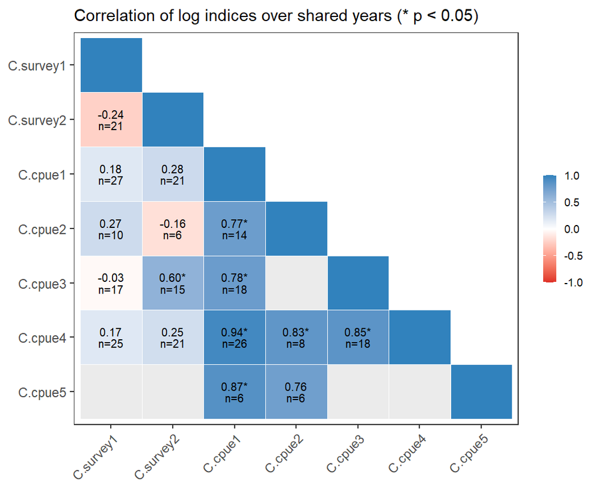

```r
jbplot_indexcor(tr.C)
```

**Between regions.** The joint indices of the two regions on one plot, and their correlation:

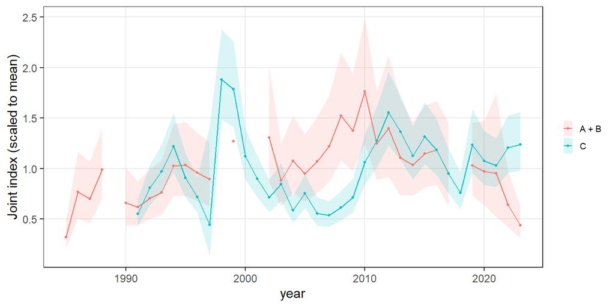

```r
jAB <- jb3_jointindex(tr.AB, name = "A + B"); jC <- jb3_jointindex(tr.C, name = "C")
reg <- rbind(data.frame(jAB, region = "A + B"), data.frame(jC, region = "C"))
reg <- do.call(rbind, lapply(split(reg, reg$region), function(z){ m <- mean(z$index, na.rm = TRUE)
  z$index <- z$index/m; z$lci <- z$lci/m; z$uci <- z$uci/m; z }))
ggplot2::ggplot(reg, ggplot2::aes(year, index, colour = region, fill = region)) +
  ggplot2::geom_ribbon(ggplot2::aes(ymin = lci, ymax = uci), alpha = 0.15, colour = NA) +
  ggplot2::geom_line() + ggplot2::geom_point(size = 0.8) +
  ggplot2::labs(y = "Joint index (scaled to mean)", colour = NULL, fill = NULL) + theme_jabba3()
```

```r
J <- merge(data.frame(year = jAB$year, AB = jAB$index), data.frame(year = jC$year, C = jC$index))
ok <- is.finite(J$AB) & is.finite(J$C)
cor.test(log(J$AB[ok]), log(J$C[ok]))[c("estimate", "p.value")]
```

```
#> $estimate
#>        cor
#> 0.05500221
#>
#> $p.value
#> [1] 0.7768844
```

**All indices in one model.** If the regions were one stock, a single trend model with all nine indices should fit them without systematic residuals. The pairwise correlations and residual diagnostics of the joint fit:

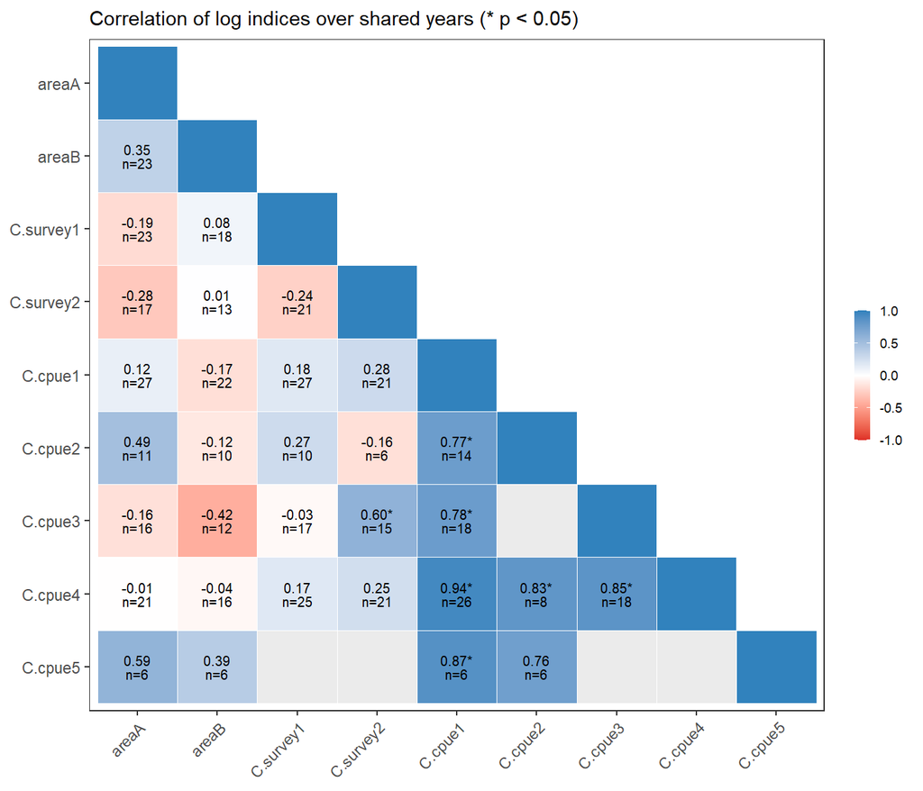

```r
tr.all <- jb3_trend(rg, run = "all regions")
jbplot_indexcor(tr.all)
```

The additional observation SD each index needs, fitted within its region and in the model with all regions:

```r
sdi <- function(f) stats::setNames(f$sdi, f$indices)
knitr::kable(data.frame(index = tr.all$indices, within.region = c(sdi(tr.AB), sdi(tr.C))[tr.all$indices],
                        all.regions = sdi(tr.all)), digits = 3, row.names = FALSE)
```

| index | within.region | all.regions |
| --- | --- | --- |
| areaA | 0.075 | 0.290 |
| areaB | 0.233 | 0.386 |
| C.survey1 | 0.561 | 0.544 |
| C.survey2 | 0.292 | 0.282 |
| C.cpue1 | 0.051 | 0.058 |
| C.cpue2 | 0.094 | 0.081 |
| C.cpue3 | 0.175 | 0.256 |
| C.cpue4 | 0.062 | 0.076 |
| C.cpue5 | 0.071 | 0.071 |

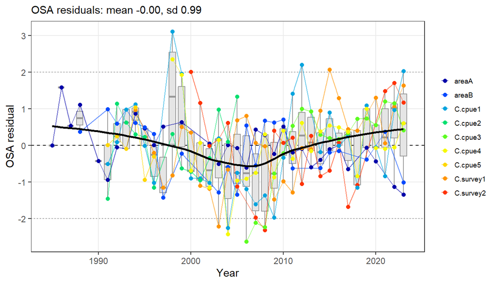

```r
jbplot_residuals(tr.all)
```

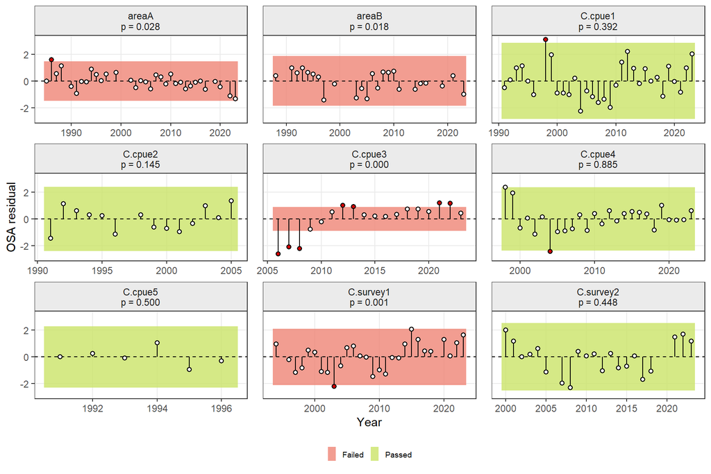

```r
p.reg <- jbplot_runs(tr.all)
p.reg
```

```r
attr(p.reg, "runs")[, c("index", "p.runs", "test")]
```

```
#>               index p.runs   test
#> areaA         areaA  0.028 Failed
#> areaB         areaB  0.018 Failed
#> C.survey1 C.survey1  0.001 Failed
#> C.survey2 C.survey2  0.448 Passed
#> C.cpue1     C.cpue1  0.392 Passed
#> C.cpue2     C.cpue2  0.145 Passed
#> C.cpue3     C.cpue3  0.000 Failed
#> C.cpue4     C.cpue4  0.885 Passed
#> C.cpue5     C.cpue5  0.500 Passed
```

**How to use this.** Agreement among regions (positive correlations, no residual patterns that separate the regions, similar trends in the regional joint indices) supports assessing the regions together with one joint index or with all indices in one model. Conflict between regions, while the indices within each region agree, suggests that the regions have different dynamics: assess them separately, or at least test the combined assessment against separate ones. The trend models cannot by themselves establish stock structure, which needs biological evidence (genetics, tagging, life history), but they show whether the abundance data are consistent with a single unit.

# 18 Special feature: catch-only assessment and auxiliary data

Most stocks have no reliable abundance index. This chapter shows how JABBA3 handles the data-limited end of the range: catch-only assessments with priors on stock status, auxiliary data such as fishing effort or an index of exploitation, and how each kind of data changes the estimate of stock status.

> **The effort and F/Fmsy series used here are hypothetical.** Bigeye tuna has no effort or F/Fmsy series in the package. Both series below (`iccat$bet$effort_hyp` and `iccat$bet$ffmsy_hyp`) were *simulated* from the F trajectory of the bigeye example fit: effort with 2% annual effort creep and lognormal noise (SD 0.15), and F/Fmsy with noise (SD 0.3) for 1990-2009 only. They are not real data. They are used only to show the methods, and their fits are partly circular, because they were simulated from an assessment that used the same catch.

## 18.1 Concept: hierarchical assessment framework

Kell et al. (2025) set out a *hierarchical assessment framework* (HAF) for biomass dynamic models, in which the assessment method follows the data available. There are four tiers:

| Tier | Data | Method |
| --- | --- | --- |
| Robust quantitative assessment | reliable abundance indices and catch | JABBA |
| Preliminary quantitative assessment | partial or short indices, catch | JABBA with scenarios and sensitivity runs |
| Auxiliary data | auxiliary indices (length-based F/Fmsy, effort), catch | auxiliary data as priors or as time series of exploitation |
| Data-limited | catch only | catch-only model with predictive priors (e.g. current depletion) |

The aim is *risk equivalence*: the risk of misclassifying stock status against $B_{MSY}$ and $F_{MSY}$ should be the same in every tier. It is measured by classification skill, for example the true skill statistic (sensitivity + specificity - 1) for $B < B_{MSY}$ or $F > F_{MSY}$. Each tier starts from *prior predictive modelling* (PPM): the model is run with the priors and the catch but without the data, as a reality check of what the assumptions alone imply. Kell et al. found that auxiliary F/Fmsy indices, especially from periods of high exploitation, substantially improve the classification of status.

JABBA3 covers all tiers with one model:

- `jb3_data(catch, indices = NULL)` gives a catch-only data set;
- `jb3_priors(status = jb3_bprior(...))` adds priors on $B/B_{MSY}$, $B/K$ or $F/F_{MSY}$ in any year, as JABBA’s `b.prior`;
- `jb3_data(auxiliary = , auxiliary.type = )` adds auxiliary series of type `"effort"`, `"f"`, `"ffmsy"`, `"bbmsy"`, `"bk"` or `"z"`;
- `jabba3(..., prior.only = TRUE)` switches off the likelihood of the indices and auxiliary data (the catch still drives the dynamics), which gives the prior predictive run.

Without an index, the posterior mode and its Laplace approximation are unreliable: there is nothing to pin down the states. `jabba3()` therefore samples with NUTS by default when there is no index or when `prior.only = TRUE` (`engine = "rtmb"` can still be set explicitly).

The runs below move up the tiers for bigeye tuna:

1. catch only (tier 4): the prior predictive run, then the same with a terminal-year $B/B_{MSY}$ prior;
2. catch + auxiliary data (tier 3): hypothetical effort with 2% creep (and a no-creep sensitivity), and a hypothetical F/Fmsy index from a period of high exploitation;
3. catch + index (tier 1): the two Japanese longline CPUE series;
4. catch + auxiliary data + index.

All runs use the Fox model with the r prior of the bigeye example, the default K and initial depletion priors, and NUTS with three chains of 4000 iterations (2000 warm-up; the `jabba3()` default).

```r
bet <- iccat$bet
pr.r <- c(0.2, 0.5)
mod  <- jb3_model(shape = "fox")
nu   <- list(chains = 3, cores = 3)   # 4000 iterations per chain (default), 2000 warm-up
```

## 18.2 Catch only: prior predictive and status priors

With catch only, the information comes from the priors on r, K and initial depletion, and from the catch itself, which has to be sustainable under the estimated production function. The prior predictive run shows what these assumptions imply:

```r
d0  <- jb3_data(bet$catch, NULL, stock = "bet")
d0
```

```
#> JABBA3 data:bet
#>   years 1950-2017 (68), catch range 808-135000
#>   catch-only: no abundance index
```

```r
pr0 <- jb3_priors(d0, r = pr.r)
co.ppm <- jabba3(d0, pr0, mod, prior.only = TRUE, nuts = nu, run = "Prior predictive")
```

Next, a prior on current status. As in JABBA’s `b.prior`, `jb3_bprior()` places a lognormal prior on $B/B_{MSY}$ (or $B/K$, $F/F_{MSY}$) in a given year; with `year = NULL` the prior applies to the terminal year. Here $B/B_{MSY} = 0.7$ in 2017 with a CV of 0.2, the kind of prior that might come from expert judgement or a length-based method:

```r
pr.b <- jb3_priors(d0, r = pr.r, status = jb3_bprior(0.7, cv = 0.2, type = "bbmsy"))
pr.b$status
```

```
#>   year  type median    log.sd
#> 1   NA BBmsy    0.7 0.1980422
```

```r
co.b <- jabba3(d0, pr.b, mod, nuts = nu, run = "Catch + B/Bmsy prior")
```

The JABBA form `status = c(0.5, 0.2, 2010, "bbmsy")` is accepted too, and several priors are combined with `rbind()` (for example `rbind(jb3_bprior(0.7, 0.2), jb3_bprior(1.2, 0.3, 2000, "ffmsy"))`).

`jbplot_priorpost_trj()` compares the two catch-only runs: trajectories, and the marginal distributions of r, K and terminal $B/B_{MSY}$:

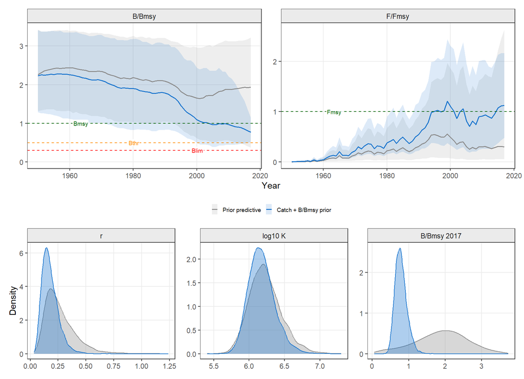

```r
jbplot_priorpost_trj(list(`Prior predictive` = co.ppm, `Catch + B/Bmsy prior` = co.b))
```

## 18.3 Catch + auxiliary data

Auxiliary data enter `jb3_data()` as a data frame (one column per series, with `auxiliary.type`) or as a named list of series. The observation model is lognormal, with the input log-scale SE plus an additional observation SD estimated per series (`jb3_model(aux.sd = NULL)`, the default) or fixed (`aux.sd = 0.15`):

- **effort**: $\log E_t \sim N(\log F_t - \log q_E - (t - t_0)\log(1 + c),\ \sigma^2)$, where $c$ is the annual effort creep (the increase in catchability per unit effort). The creep is fixed with `jb3_model(effort.creep = 0.02)` or estimated with `effort.creep = "estimate"` and a normal prior `jb3_priors(creep = c(0.02, 0.02))`. $q_E$ is estimated.
- **ffmsy, bbmsy, bk**: the status quantity itself with $q = 1$ (absolute status estimates, e.g. from length-based indicators or another assessment; set `aux.q = NA` to estimate a scaling instead);
- **f** ($q = 1$) and **z** (estimated $q$, as JABBA).

The hypothetical bigeye series:

```r
head(bet$effort_hyp, 3)
```

```
#>   year effort
#> 1 1960  89.51
#> 2 1961 143.10
#> 3 1962 210.60
```

```r
head(bet$ffmsy_hyp, 3)
```

```
#>   year  ffmsy  se
#> 1 1990 0.4797 0.3
#> 2 1991 0.7083 0.3
#> 3 1992 0.9433 0.3
```

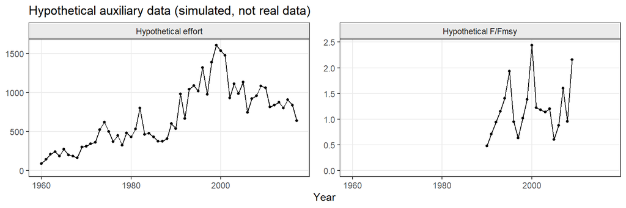

```r
ax <- rbind(data.frame(year = bet$effort_hyp$year, value = bet$effort_hyp$effort, series = "Hypothetical effort"),
            data.frame(year = bet$ffmsy_hyp$year, value = bet$ffmsy_hyp$ffmsy, series = "Hypothetical F/Fmsy"))
ggplot2::ggplot(ax, ggplot2::aes(year, value)) + ggplot2::geom_line() + ggplot2::geom_point(size = 1) +
  ggplot2::facet_wrap(~series, scales = "free_y") + ggplot2::expand_limits(y = 0) +
  ggplot2::labs(x = "Year", y = NULL, title = "Hypothetical auxiliary data (simulated, not real data)") + theme_jabba3()
```

Catch + hypothetical effort, with the 2% creep it was simulated with, and with no creep as a sensitivity:

```r
d.e <- jb3_data(bet$catch, NULL, stock = "bet", auxiliary = bet$effort_hyp, auxiliary.type = "effort")
d.e
```

```
#> JABBA3 data:bet
#>   years 1950-2017 (68), catch range 808-135000
#>   catch-only: no abundance index
#>   auxiliary effort (effort): 58 obs, 1960-2017
```

```r
co.e  <- jabba3(d.e, pr0, jb3_model(shape = "fox", effort.creep = 0.02), nuts = nu, run = "Catch + effort (creep 2%)")
co.e0 <- jabba3(d.e, pr0, jb3_model(shape = "fox", effort.creep = 0),    nuts = nu, run = "Catch + effort (no creep)")
```

Catch + hypothetical F/Fmsy index, 1990-2009 only, with its SE of 0.3:

```r
d.f <- jb3_data(bet$catch, NULL, stock = "bet", auxiliary = bet$ffmsy_hyp[, c("year", "ffmsy")],
                auxiliary.se = bet$ffmsy_hyp[, c("year", "se")], auxiliary.type = "ffmsy")
co.f <- jabba3(d.f, pr0, mod, nuts = nu, run = "Catch + F/Fmsy index")
```

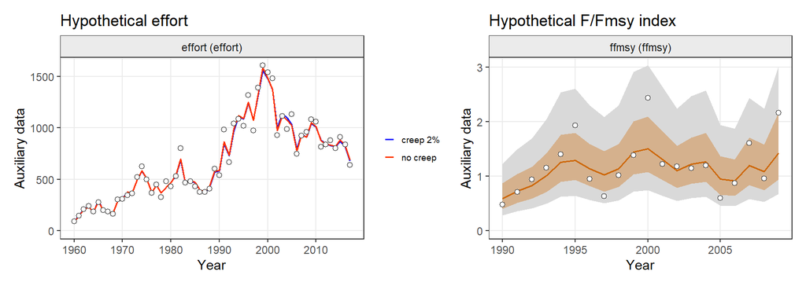

```r
patchwork::wrap_plots(
  jbplot_auxfits(list(`creep 2%` = co.e, `no creep` = co.e0), title = "Hypothetical effort"),
  jbplot_auxfits(co.f, title = "Hypothetical F/Fmsy index"), ncol = 2, widths = c(1, 1))
```

Effort informs the *trend* in F, not its scale ($q_E$ is estimated), and the creep assumption is decisive: without creep, the same nominal effort implies a steadily falling F in recent years, and the stock looks lightly exploited ($B/B_{MSY}$ about 2 in 2017). With the 2% creep the series was simulated with, the estimate is close to the index-based assessment, which is partly by construction (the effort was simulated from that assessment’s F). An absolute F/Fmsy index informs the *scale* of exploitation: in 1990-2009 the F/Fmsy estimates of the catch + F/Fmsy run are about as precise as those of the index-based run. After 2009 there is no information on F, and the terminal F/Fmsy interval widens again.

## 18.4 Catch + index, and catch + auxiliary data + index

```r
d.i  <- jb3_data(bet$catch, bet$cpue, bet$se, stock = "bet")
co.i <- jabba3(d.i, jb3_priors(d.i, r = pr.r), mod, engine = "nuts", nuts = nu, run = "Catch + index")
d.ie <- jb3_data(bet$catch, bet$cpue, bet$se, stock = "bet",
                 auxiliary = bet$effort_hyp, auxiliary.type = "effort")
co.ie <- jabba3(d.ie, jb3_priors(d.ie, r = pr.r), jb3_model(shape = "fox", effort.creep = 0.02),
                engine = "nuts", nuts = nu, run = "Catch + effort + index")
```

## 18.5 Moving up the tiers

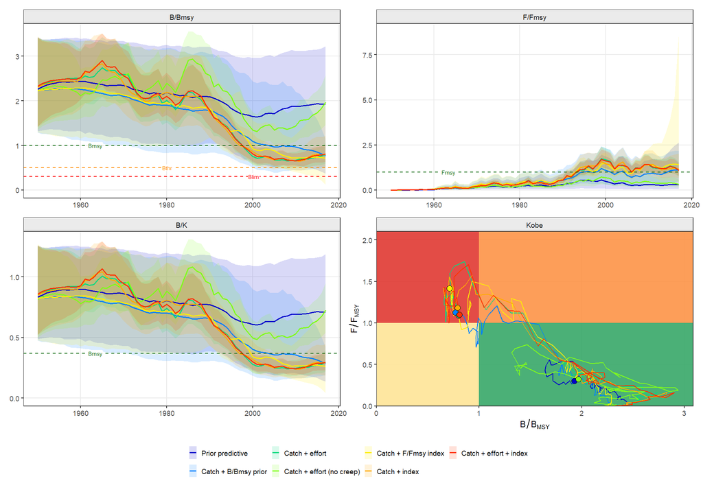

```r
co.runs <- list(`Prior predictive` = co.ppm, `Catch + B/Bmsy prior` = co.b, `Catch + effort` = co.e,
                `Catch + effort (no creep)` = co.e0, `Catch + F/Fmsy index` = co.f, `Catch + index` = co.i,
                `Catch + effort + index` = co.ie)
jabbaplot3(co.runs, panels = c("B/Bmsy", "F/Fmsy", "B/K", "kobe"), ncol = 2)
```

```r
pt <- jb3_partable(co.runs, format = "wide")
knitr::kable(pt[pt$Parameter %in% c("K", "r", "MSY", "qA.effort", "sdA.effort", "sdA.ffmsy", "B/Bmsy", "F/Fmsy"), ],
             row.names = FALSE, caption = "Posterior medians (95% intervals); the effort and F/Fmsy data are hypothetical")
```

Posterior medians (95% intervals); the effort and F/Fmsy data are hypothetical

| Parameter | Prior predictive | Catch + B/Bmsy prior | Catch + effort | Catch + effort (no creep) | Catch + F/Fmsy index | Catch + index | Catch + effort + index |
| --- | --- | --- | --- | --- | --- | --- | --- |
| K | 1,620,000 (686,000-5,510,000) | 1,450,000 (723,000-3,890,000) | 1,270,000 (755,000-2,510,000) | 1,720,000 (894,000-4,360,000) | 1,390,000 (752,000-2,890,000) | 1,400,000 (819,000-2,800,000) | 1,310,000 (809,000-2,330,000) |
| r | 0.236 (0.0914-0.606) | 0.166 (0.0731-0.355) | 0.179 (0.0867-0.314) | 0.184 (0.0878-0.33) | 0.149 (0.0704-0.308) | 0.162 (0.0792-0.287) | 0.17 (0.0913-0.292) |
| MSY | 131,000 (68,500-569,000) | 88,700 (57,700-170,000) | 84,100 (66,900-104,000) | 114,000 (72,700-233,000) | 78,000 (52,300-110,000) | 83,300 (64,200-106,000) | 82,500 (66,900-98,600) |
| B/Bmsy | 1.93 (0.368-3.22) | 0.77 (0.52-1.14) | 0.802 (0.589-1.07) | 1.97 (1.46-2.59) | 0.712 (0.12- 1.9) | 0.793 (0.503-1.21) | 0.809 (0.628-1.03) |
| F/Fmsy | 0.3 (0.0526-2.63) | 1.12 (0.481-2.16) | 1.09 (0.754-1.56) | 0.321 (0.138-0.597) | 1.41 (0.468-8.79) | 1.18 (0.656-2.04) | 1.1 (0.798-1.49) |
| qA.effort |  |  | 0.0000918 (0.000046-0.000159) | 0.0000846 (0.0000314-0.000178) |  |  | 0.0000876 (0.0000473-0.000148) |
| sdA.effort |  |  | 0.0469 (0.0203-0.103) | 0.0464 (0.0201-0.104) |  |  | 0.0482 (0.0202-0.102) |
| sdA.ffmsy |  |  |  |  | 0.0945 (0.0245-0.313) |  |  |

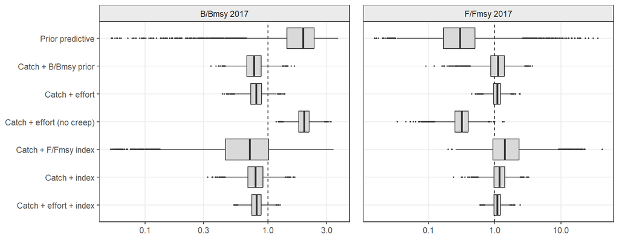

```r
stat <- do.call(rbind, lapply(names(co.runs), function(n){ f <- co.runs[[n]]; ly <- as.character(max(f$years))
  rbind(data.frame(run = n, quantity = "B/Bmsy 2017", value = f$draws$`B/Bmsy`[, ly]),
        data.frame(run = n, quantity = "F/Fmsy 2017", value = f$draws$`F/Fmsy`[, ly])) }))
stat$run <- factor(stat$run, rev(names(co.runs)))
ggplot2::ggplot(stat, ggplot2::aes(value, run)) + ggplot2::geom_vline(xintercept = 1, linetype = 2) +
  ggplot2::geom_boxplot(outlier.size = 0.3, fill = "grey85") + ggplot2::scale_x_log10() +
  ggplot2::facet_wrap(~quantity, scales = "free_x") + ggplot2::labs(x = NULL, y = NULL) + theme_jabba3()
```

The probability of being overfished, $P(B < B_{MSY})$, and of overfishing, $P(F > F_{MSY})$, in 2017:

```r
knitr::kable(do.call(rbind, lapply(names(co.runs), function(n){ f <- co.runs[[n]]
  data.frame(run = n, `P(B<Bmsy)` = mean(f$draws$`B/Bmsy`[, "2017"] < 1), `P(F>Fmsy)` = mean(f$draws$`F/Fmsy`[, "2017"] > 1),
             check.names = FALSE) })), digits = 2)
```

| run | P(B<Bmsy) | P(F>Fmsy) |
| --- | --- | --- |
| Prior predictive | 0.12 | 0.09 |
| Catch + B/Bmsy prior | 0.90 | 0.63 |
| Catch + effort | 0.94 | 0.68 |
| Catch + effort (no creep) | 0.00 | 0.00 |
| Catch + F/Fmsy index | 0.74 | 0.71 |
| Catch + index | 0.86 | 0.73 |
| Catch + effort + index | 0.95 | 0.71 |

Prior against posterior for the full assessment (catch + effort + index), with the prior predictive run as the reference:

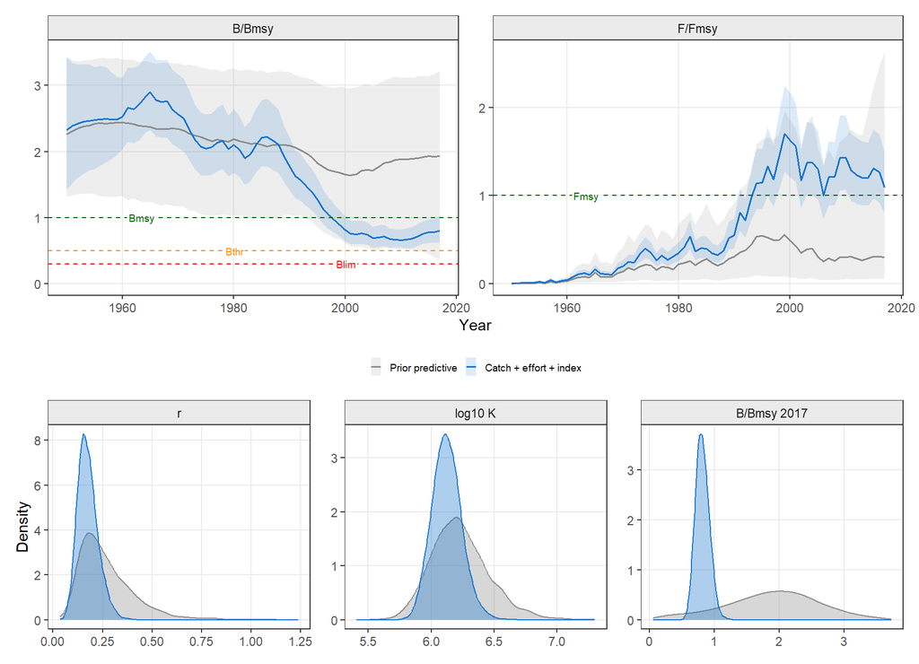

```r
jbplot_priorpost_trj(co.ppm, co.ie, labels = c("Prior predictive", "Catch + effort + index"))
```

## 18.6 How much do the data add? Prior-posterior contraction

The prior predictive run is also the reference for a diagnostic of what each tier adds. `jb3_contraction()` compares each quantity of a fit with the prior predictive run (log scale):

- **contraction** = 1 − var(posterior)/var(prior predictive), the share of the prior uncertainty removed by the data (0: the data add nothing; 1: fully determined by the data);
- **shift** = (mean(posterior) − mean(prior predictive))/sd(prior predictive), how far the data move the estimate, in prior SDs.

Low contraction means a quantity is prior-driven; a large shift means the data pull it into the tail of the prior (prior-data conflict); high contraction with a moderate shift means it is informed by the data.

> **Source.** The diagnostic is adapted from the *posterior shrinkage* versus *posterior z-score* plot of Betancourt (2018), part of the principled Bayesian workflow of Schad et al. (2021). Betancourt computes shrinkage $= 1 - \mathrm{var(posterior)}/\mathrm{var(prior)}$ and the z-score $=(\mathrm{mean(posterior)} - \theta_{true})/\mathrm{sd(posterior)}$ over simulated data sets with a known true value $\theta_{true}$, to check a model design before it is fitted to real data. A real assessment has no true value, so JABBA3 replaces the z-score by the shift from the prior predictive mean, which measures prior-data conflict rather than calibration, and uses the prior predictive run as the reference distribution; `contraction.pdf`, against the stated prior density, is the version closest to Betancourt’s shrinkage. The class names and the thresholds (`contraction.min = 0.25`, `shift.max = 2`) are JABBA3 choices, not from these papers. In simulation testing, where the truth is known, Betancourt’s original form applies directly. By default the prior predictive run is made with the fit’s own priors, model and catch (`jb3_contraction(fit)` runs it with NUTS). Here all runs are compared with the common prior predictive run `co.ppm` (catch and the r, K and initial-depletion priors), so that the status prior is treated as one of the tiers:

```r
ct <- jb3_contraction(co.runs[-1], prior = rep(list(co.ppm), length(co.runs) - 1), years = c(1990, 2017))
w <- reshape(as.data.frame(ct)[c("run", "quantity", "contraction")], idvar = "quantity", timevar = "run", direction = "wide")
names(w) <- sub("^contraction\\.", "", names(w))
knitr::kable(w, digits = 2, row.names = FALSE, caption = "Contraction relative to the prior predictive run")
```

Contraction relative to the prior predictive run

| quantity | Catch + B/Bmsy prior | Catch + effort | Catch + effort (no creep) | Catch + F/Fmsy index | Catch + index | Catch + effort + index |
| --- | --- | --- | --- | --- | --- | --- |
| K | 0.34 | 0.66 | 0.41 | 0.57 | 0.65 | 0.73 |
| r | 0.32 | 0.56 | 0.52 | 0.40 | 0.55 | 0.63 |
| MSY | 0.76 | 0.96 | 0.70 | 0.88 | 0.95 | 0.97 |
| bkinit | -0.02 | 0.00 | -0.05 | -0.03 | 0.01 | 0.01 |
| B/Bmsy 1990 | -0.33 | 0.78 | 0.79 | 0.37 | 0.57 | 0.84 |
| B/Bmsy 2017 | 0.86 | 0.92 | 0.93 | -0.56 | 0.83 | 0.94 |
| F/Fmsy 1990 | 0.64 | 0.94 | 0.73 | 0.92 | 0.88 | 0.95 |
| F/Fmsy 2017 | 0.84 | 0.96 | 0.85 | 0.40 | 0.91 | 0.97 |

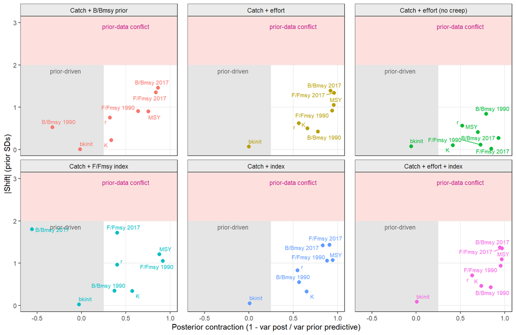

```r
jbplot_contraction(ct)
```

A catch-only fit compared with *its own* prior predictive run, which keeps the status prior, has a contraction of zero by construction, and the diagnostic says so:

```r
cb <- jb3_contraction(co.b, nuts = nu)
knitr::kable(as.data.frame(cb)[c("quantity", "prior.median", "post.median", "contraction", "contraction.pdf", "class")],
             digits = 3, row.names = FALSE)
```

| quantity | prior.median | post.median | contraction | contraction.pdf | class |
| --- | --- | --- | --- | --- | --- |
| K | 1.50e+06 | 1.45e+06 | -0.068 | 0.739 | prior-driven |
| r | 1.60e-01 | 1.66e-01 | -0.051 | 0.353 | prior-driven |
| MSY | 8.83e+04 | 8.87e+04 | -0.014 | NA | prior-driven |
| bkinit | 8.37e-01 | 8.43e-01 | 0.030 | 0.195 | prior-driven |
| B/Bmsy 2017 | 7.63e-01 | 7.70e-01 | -0.005 | NA | prior-driven |
| F/Fmsy 2017 | 1.14e+00 | 1.12e+00 | -0.006 | NA | prior-driven |

`contraction.pdf` compares the posterior of r, K and initial depletion with the stated prior density rather than with the prior predictive run. It shows what the catch and the status prior do to the r and K priors even without any data: the variance of log K is reduced by about 75% and that of log r by about 35%, because only combinations under which the stock survives the catch history and ends near the status prior remain (the CMSY logic). This is a check of the priors (whether much of the prior is incompatible with the catch), not a reason to narrow them: using the catch-conditioned r and K as priors would count the catch twice.

## 18.7 Non-centred process deviations

When the data say little about the states, as in a catch-only run, the process deviations and their SD form a “funnel” that NUTS samples poorly in the usual (centred) form. In the non-centred form NUTS samples standard normal innovations $z_t \sim N(0, 1)$ instead, and the deviations follow from

$$d_t = \rho\, d_{t-1} + \sigma_t \sqrt{1 - \rho^2}\, z_t,
\qquad \log P_t = \log \bar P_t + d_t,$$

with the production lag, bias correction, random walk and depletion-dependent SD exactly as in the centred form (the model is the same; only the coordinates of the sampler change). It is selected with `jb3_model(param = "noncentred")`; the default is `"centred"`, and the posterior mode always uses the centred form, where the Laplace approximation needs the states themselves. `jb3_nuts_ess()` gives the bulk and tail ESS of the derived states, also per 1000 draws, to compare the two:

```r
ess <- function(d, pr, p, ...) attr(jb3_nuts_ess(jabba3(d, pr, jb3_model(shape = "fox", param = p), nuts = nu, ...)), "summary")
rbind(ess(d.i, jb3_priors(d.i, r = pr.r), "centred", engine = "nuts"), ess(d.i, jb3_priors(d.i, r = pr.r), "noncentred", engine = "nuts"),
      ess(d0, pr.b, "centred"), ess(d0, pr.b, "noncentred"))
```

| Data | Form | min / median bulk ESS per 1000 draws, B/Bmsy | min tail ESS per 1000, B/Bmsy | Divergent transitions | Run time (s) |
| --- | --- | --- | --- | --- | --- |
| catch + index | centred | 43 / 54 | 92 | 0 | 33 |
| catch + index | non-centred | 113 / 327 | 42 | 1016 | 227 |
| catch + B/Bmsy prior | centred | 72 / 134 | 108 | 0 | 23 |
| catch + B/Bmsy prior | non-centred | 313 / 813 | 133 | 394 | 280 |

*Three chains of 2000 iterations (3000 post-warm-up draws); F/Fmsy behaves the same way.*

The non-centred form gives a higher bulk ESS per draw, but many divergent transitions, so its draws are not reliable, and it is seven to twelve times slower. The reason is the production model: each state depends on *all* earlier innovations through the nonlinear surplus production and the catch removals, so the non-centred coordinates are strongly and nonlinearly correlated, and the curvature changes sharply where the catch approaches the biomass. The centred form had no divergences in either case and is the default. The non-centred form remains an option for short series or very weakly informed states, always to be checked with `jb3_nuts_diags()`.

> The NUTS runs of this chapter took 6.3 minutes in total (three chains of 4000 iterations each, run in parallel).

# 19 Special feature: Selex

Standard JABBA3, like JABBA, models the exploitable biomass (EB) that the fishery and the indices see. Where the fishery selects fish before maturity, or selectivity changes over time, EB and spawning biomass (SB) diverge, and an SPM on EB gives biased status relative to the SB-based reference points of advice. The Selex model (JABBA-Select; Winker et al. 2020) takes SB as the state and maps the indices and removals to it through the equilibrium ratio of the exploitable stock to SB as a function of depletion. This chapter covers

- the Selex model and the EB/SB curves from life history and length-based selectivity (`jb3_selex()`);
- a change in selectivity, with the r prior from the age-structured equilibrium (`jb3_asem_prior()`): the simulated KOBsim data of JABBA-Select, with the truth;
- indices in numbers: the bigeye joint longline index.

## 19.1 The Selex model

With `ebsb` the state is spawning biomass and the indices and removals are mapped to it through the equilibrium ratio of exploitable to spawning biomass, a function of depletion given as a curve `c(u1, u2, u3, P1, P2)` (or a named list of curves, one per selectivity), assigned to indices with `ebsb.index` and to the removals with `ebsb.catch`. The priors are then on the spawning-biomass scale. The curves come from an age-structured equilibrium analysis (e.g. FLBRP) or from a JABBA Selex setup via `jbinput2jabba3()`. `jb3_selex()` computes the curves from life history and length-based selectivity, and `jb3_asem_prior()` the matching r prior (KOBsim example below).

`jbplot_ebsb_status()` shows the spawning biomass status (the state) with the exploitable biomass status implied by each curve, EB/EB<sub>MSY</sub> = (SB/SB<sub>MSY</sub>) $\times$ $\rho$(SB/K)/$\rho$(SB<sub>MSY</sub>/K). With an illustrative curve:

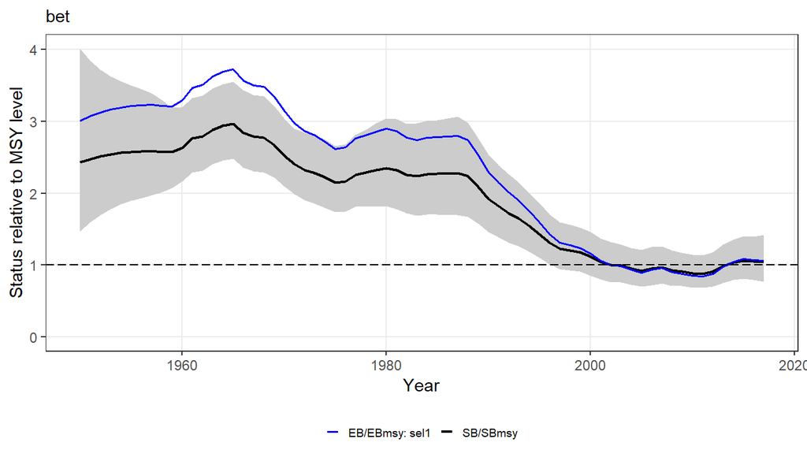

```r
fsel <- jabba3(d, pr, jb3_model(shape = "fox", ebsb = c(0.6, 1.2, 3, 0.1, 1)), osa = FALSE)
jbplot_ebsb_status(fsel)
```